# Understanding Your Guests: A Data-Driven Guide to Pricing, Stay Length, and Cancellations

City Hotel Lisbon - Booking Intelligence Report

Petronela Tabalae, Divya Shori, Lorena Zovkic

Juni 2026

```r
hotel_data <- hotel_data %>%
  mutate(
    across(where(is.character), trimws),
    Agent   = ifelse(Agent   %in% c("NULL", ""), NA, Agent),
    Company = ifelse(Company %in% c("NULL", ""), NA, Company),
    total_stays = StaysInWeekendNights + StaysInWeekNights,
    arrival_season = case_when(
      ArrivalDateMonth %in% c("March", "April", "May")            ~ "Spring",
      ArrivalDateMonth %in% c("June", "July", "August")           ~ "Summer",
      ArrivalDateMonth %in% c("September", "October", "November") ~ "Autumn",
      TRUE                                                          ~ "Winter"
    ),
    is_via_agent = ifelse(is.na(Agent), 0L, 1L),
    country_region = case_when(
      Country %in% c("PRT","ESP","FRA","ITA","DEU","BEL",
                     "NLD","CHE","AUT","LUX","AND")               ~ "Western Europe",
      Country %in% c("GBR","IRL","DNK","SWE","NOR","FIN",
                     "ISL","POL","CZE","SVK","HUN")               ~ "N/E Europe",
      Country %in% c("USA","CAN","BRA","ARG","MEX","COL")         ~ "Americas",
      TRUE                                                          ~ "Other"
    ),
    Children = ifelse(is.na(Children), 0, Children)
  )

hotel_data <- hotel_data[, setdiff(names(hotel_data),
                          c("ReservationStatus", "ReservationStatusDate", "Company"))]

hotel_data <- hotel_data %>%
  mutate(
    MarketSegment    = relevel(factor(MarketSegment),  ref = "Online TA"),
    CustomerType     = relevel(factor(CustomerType),   ref = "Transient"),
    DepositType      = relevel(factor(DepositType),    ref = "No Deposit"),
    Meal             = relevel(factor(Meal),           ref = "BB"),
    arrival_season   = relevel(factor(arrival_season), ref = "Summer"),
    country_region   = relevel(factor(country_region), ref = "Western Europe"),
    ReservedRoomType = factor(ReservedRoomType),
    IsCanceled       = as.integer(IsCanceled),
    IsRepeatedGuest  = as.integer(IsRepeatedGuest)
  )

mean_lt   <- round(mean(hotel_data$LeadTime), 1)
mean_temp <- round(mean(hotel_data$avg_temp_c, na.rm = TRUE), 1)

cat("Dataset ready:", nrow(hotel_data), "bookings,", ncol(hotel_data), "variables\n")
```

```
## Dataset ready: 79330 bookings, 35 variables
```

# Executive Summary

#### 💰 Pricing Opportunity

Guests who book directly pay the highest rates. A measurable early-booking discount exists in the data; structured early-bird pricing tiers are both evidence-based and commercially viable.

#### 🏨 Stay Length Gap

Summer leisure guests stay significantly longer than Corporate visitors. Stay-extension promotions targeting Online TA leisure bookings in peak season offer the clearest incremental revenue opportunity.

#### ⚠️ Cancellation Risk

41.7% of bookings are cancelled. Seven signals available at booking time — including lead time, deposit type, special requests, and prior cancellation history — identify high-risk reservations with over 87% accuracy.

# 1 Introduction

A hotel room unsold tonight is revenue gone forever. Unlike a retailer who can hold unsold stock and discount it next week, a hotel cannot recover a night that passed empty. This makes forecasting of price, stay length, and cancellations not a strategic aspiration but an operational necessity.

This report presents a machine learning analysis of **79,330 booking records** from a city hotel in Lisbon, Portugal, covering reservations made between July 2015 and August 2017. The data, published by Antonio, Almeida, and Nunes (2019), captures the complete lifecycle of each booking: when it was made, who made it, what was requested, what was paid, and whether the guest ultimately arrived. Monthly weather data for Lisbon (temperature, precipitation, and sunshine hours) from the Open-Meteo historical archive is layered in as additional context.

Three questions drive the analysis, each with direct commercial stakes:

> **On Pricing:** Which booking and seasonal characteristics determine how much a guest pays per night, and by how much?

> **On Stay Length:** Which guest segments book the longest stays, and how large are the differences?

> **On Cancellations:** What information available at the time of booking most reliably predicts whether a reservation will be cancelled?

## 1.1 Our Analytical Approach

Six models address these questions. Pricing and stay length each warrant a single well-specified model; these are questions where understanding the *why* matters as much as the prediction. Cancellation risk is approached through four models of increasing complexity, because it is the highest-stakes problem and the one most likely to contain patterns that simpler models miss.

Table 1: Six models across three business questions. Models 3–6 form a deliberate progression; each step tests one specific assumption made by the model above it.

| Model | Business Question | What It Tells Us |
| --- | --- | --- |
| Model 1: Linear Model | Pricing | Which factors drive room price up or down, and by exactly what percentage. |
| Model 2: Poisson GLM | Stay Length | Which guest types stay longest and by how much, as a rate ratio. |
| Model 3: Logistic Regression | Cancellation | Which booking signals predict cancellation. Transparent, directly explainable to stakeholders. |
| Model 4: Generalised Additive Model | Cancellation | Where the logistic model’s straight-line assumption breaks down, and what the true curve looks like. |
| Model 5: Support Vector Machine | Cancellation | Whether allowing the model to learn feature interactions improves accuracy over additive models. |
| Model 6: Neural Network | Cancellation | The most flexible approach: learns its own patterns end-to-end. Permutation importance reveals which signals it uses differently. |

All models are trained on 80% of the data and evaluated on the remaining 20%, bookings the model never saw during training. Every performance figure in this report reflects genuine out-of-sample accuracy.

# 2 What the Data Reveals

Before fitting any model, we examined the data to understand its structure, identify the patterns that would drive each analysis, and flag anything that needed to be handled carefully. Every modelling decision in the sections that follow traces back to a finding here.

## 2.1 Who Books, and How

The dataset spans 79,330 bookings across three years, covering six dimensions of each reservation. Three variables are excluded from all analysis: `ReservationStatus` and `ReservationStatusDate` encode the cancellation outcome directly (using them to predict cancellation would be like marking your own exam), and `Company` is missing for 94.7% of bookings and carries no usable information.

[output not shown]

## 2.2 Demand Is Deeply Seasonal and Predictably So

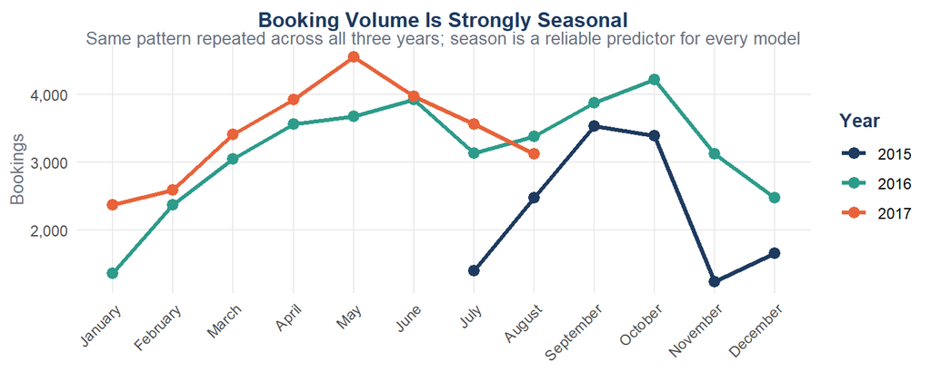

```r
hotel_data %>%
  mutate(
    ArrivalDateMonth = factor(ArrivalDateMonth, levels = month.name),
    Year = factor(ArrivalDateYear)
  ) %>%
  count(ArrivalDateMonth, Year) %>%
  ggplot(aes(x = ArrivalDateMonth, y = n, colour = Year, group = Year)) +
  geom_line(linewidth = 1.2) +
  geom_point(size = 2.8) +
  scale_colour_manual(values = c("2015" = P$navy, "2016" = P$teal, "2017" = P$orange)) +
  scale_x_discrete(guide = guide_axis(angle = 45)) +
  scale_y_continuous(labels = comma_format()) +
  labs(title = "Booking Volume Is Strongly Seasonal",
       subtitle = "Same pattern repeated across all three years; season is a reliable predictor for every model",
       x = NULL, y = "Bookings", colour = "Year") +
  theme_report()
```

## 2.3 The Booking Landscape: Price, Stay Length, and Cancellation by Segment

Market segment is the single most powerful organising variable in this data. It separates bookings by how much guests pay, how long they stay, and how likely they are to cancel, the three core dimensions of this entire analysis.

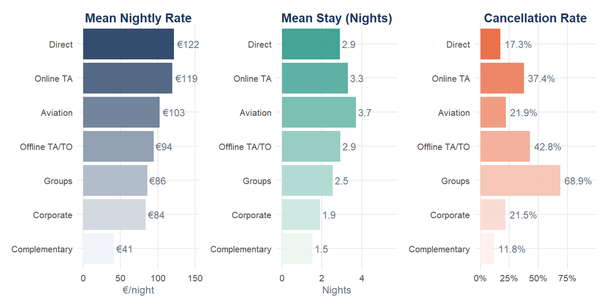

```r
seg_summary <- hotel_data %>%
  filter(!as.character(MarketSegment) %in% c("Undefined")) %>%
  group_by(MarketSegment) %>%
  summarise(
    mean_adr    = mean(ADR[ADR > 0], na.rm = TRUE),
    mean_stays  = mean(total_stays[total_stays > 0], na.rm = TRUE),
    cancel_rate = mean(IsCanceled),
    n           = n(), .groups = "drop"
  )

p_adr_seg <- ggplot(seg_summary,
                    aes(x = reorder(as.character(MarketSegment), mean_adr),
                        y = mean_adr, fill = as.character(MarketSegment))) +
  geom_col(alpha = 0.9, show.legend = FALSE) +
  geom_text(aes(label = paste0("€", round(mean_adr))), hjust = -0.15, size = 3,
            colour = P$grey) +
  coord_flip() +
  scale_fill_manual(values = setNames(
    colorRampPalette(c(P$light, P$navy))(length(unique(as.character(seg_summary$MarketSegment)))),
    levels(reorder(as.character(seg_summary$MarketSegment), seg_summary$mean_adr)))) +
  scale_y_continuous(limits = c(0, 148)) +
  labs(title = "Mean Nightly Rate", x = NULL, y = "€/night") +
  theme_report(10)

p_stays_seg <- ggplot(seg_summary,
                      aes(x = reorder(as.character(MarketSegment), mean_adr),
                          y = mean_stays, fill = as.character(MarketSegment))) +
  geom_col(alpha = 0.9, show.legend = FALSE) +
  geom_text(aes(label = round(mean_stays, 1)), hjust = -0.15, size = 3, colour = P$grey) +
  coord_flip() +
  scale_fill_manual(values = setNames(
    colorRampPalette(c("#EBF5F0", P$teal))(length(unique(as.character(seg_summary$MarketSegment)))),
    levels(reorder(as.character(seg_summary$MarketSegment), seg_summary$mean_adr)))) +
  scale_y_continuous(limits = c(0, 5.5)) +
  labs(title = "Mean Stay (Nights)", x = NULL, y = "Nights") +
  theme_report(10)

p_cancel_seg <- ggplot(seg_summary,
                       aes(x = reorder(as.character(MarketSegment), mean_adr),
                           y = cancel_rate, fill = as.character(MarketSegment))) +
  geom_col(alpha = 0.9, show.legend = FALSE) +
  geom_text(aes(label = scales::percent(cancel_rate, accuracy = 0.1)),
            hjust = -0.15, size = 3, colour = P$grey) +
  coord_flip() +
  scale_fill_manual(values = setNames(
    colorRampPalette(c("#FEF0EC", P$orange))(length(unique(as.character(seg_summary$MarketSegment)))),
    levels(reorder(as.character(seg_summary$MarketSegment), seg_summary$mean_adr)))) +
  scale_y_continuous(labels = scales::percent_format(), limits = c(0, 0.95)) +
  labs(title = "Cancellation Rate", x = NULL, y = NULL) +
  theme_report(10)

p_adr_seg + p_stays_seg + p_cancel_seg
```

**What this means commercially.** Online TA dominates volume at 49% of all bookings, making it the most consequential segment for any revenue decision. Direct bookings command the highest rates, suggesting investment in direct channel marketing pays off. Groups cancel at nearly 69%, which warrants either stricter deposit policies or targeted retention outreach for this segment.

## 2.4 Five Data Decisions That Apply to Every Model

The exploratory analysis surfaced five issues that required a consistent response before any model was fitted:

1. **Log-transform nightly rate:** ADR is right-skewed with a long upper tail. Log-transformation produces a symmetric distribution and makes model coefficients interpretable as percentage price changes.
2. **Remove zero-rate bookings from pricing models:** 1,208 complimentary rooms are not market prices and would distort the pricing analysis.
3. **Remove zero-night records from stay analysis:** 331 bookings with no recorded nights cannot be modelled as a stay.
4. **Centre continuous predictors:** Lead time and temperature are centred at their means so model outputs describe the most common booking profile, not an impossible baseline of zero days and zero degrees.
5. **Handle the Non Refund deposit anomaly:** Bookings with a non-refundable deposit show a 99.8% cancellation rate across 12,868 records. This is almost certainly a back-office recording convention; no genuine guest segment cancels at near certainty. It is included in cancellation models as a predictive signal but is never interpreted as a lever the hotel can pull.

# 3 Model 1: What Drives Nightly Room Rates?

Section lead: Divya Shori

> **Which booking and seasonal characteristics determine the price a guest pays per night, and by exactly how much?**

Room price is the primary revenue lever in a hotel. Even small, systematic differences across segments or seasons compound across thousands of bookings into significant revenue outcomes. A model that quantifies these differences, for example “Direct bookings sustain a 12% price premium over Online TA, after controlling for season, room type, and timing,” turns pricing intuition into auditable evidence.

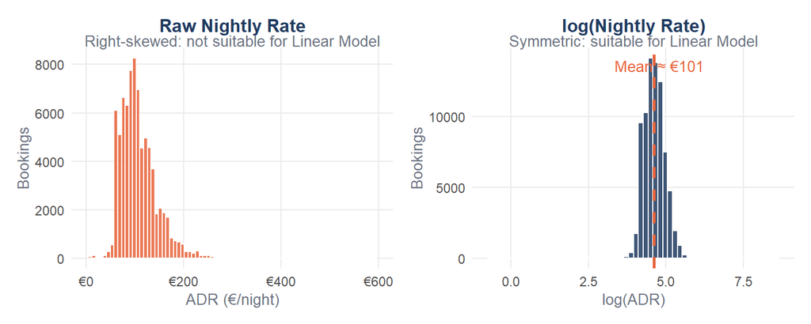

Figure 3: Raw nightly rate (left) is right-skewed and unsuitable for a Linear Model. After log-transformation (right) the distribution is symmetric, confirming log(ADR) as the correct response variable.

```r
hotel_lm <- hotel_data %>%
  filter(ADR > 0,
         !as.character(MarketSegment) %in% c("Complementary", "Undefined")) %>%
  mutate(
    log_adr      = log(ADR),
    LeadTime_c   = LeadTime   - mean(LeadTime,   na.rm = TRUE),
    avg_temp_c_c = avg_temp_c - mean(avg_temp_c, na.rm = TRUE)
  )
hotel_lm$MarketSegment <- droplevels(hotel_lm$MarketSegment)

mean_lt   <- round(mean(hotel_data$LeadTime), 1)
mean_temp <- round(mean(hotel_data$avg_temp_c, na.rm = TRUE), 1)

p_raw <- ggplot(hotel_lm, aes(x = ADR)) +
  geom_histogram(bins = 80, fill = P$orange, colour = "white", alpha = 0.85) +
  scale_x_continuous(labels = dollar_format(prefix = "€"), limits = c(0, 600)) +
  labs(title = "Raw Nightly Rate",
       subtitle = "Right-skewed: not suitable for Linear Model",
       x = "ADR (€/night)", y = "Bookings") +
  theme_report()

p_log <- ggplot(hotel_lm, aes(x = log_adr)) +
  geom_histogram(bins = 60, fill = P$navy, colour = "white", alpha = 0.85) +
  geom_vline(xintercept = mean(hotel_lm$log_adr),
             linetype = "dashed", colour = P$orange, linewidth = 0.9) +
  annotate("text", x = mean(hotel_lm$log_adr) + 0.18, y = Inf, vjust = 2,
           label = paste0("Mean ≈ €", round(exp(mean(hotel_lm$log_adr)), 0)),
           size = 3.5, colour = P$orange) +
  labs(title = "log(Nightly Rate)",
       subtitle = "Symmetric: suitable for Linear Model",
       x = "log(ADR)", y = "Bookings") +
  theme_report()

p_raw + p_log
```

Two continuous predictors are centred before fitting: lead time (mean = 109.7 days) and monthly temperature (mean = 17.6°C). This ensures the model intercept has a concrete meaning: the expected rate for a typical booking at typical timing and weather, rather than a mathematical extrapolation to impossible values.

## 3.1 What Predicts Price?

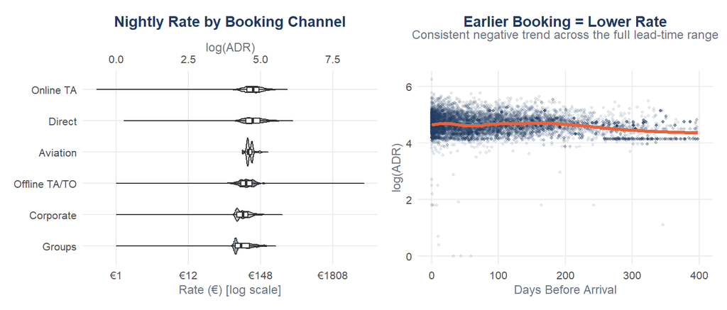

```r
p_seg <- ggplot(hotel_lm,
                aes(x = reorder(MarketSegment, log_adr, median),
                    y = log_adr, fill = MarketSegment)) +
  geom_violin(trim = TRUE, alpha = 0.6, show.legend = FALSE) +
  geom_boxplot(width = 0.15, fill = "white", outlier.shape = NA, show.legend = FALSE) +
  coord_flip() +
  scale_fill_manual(values = colorRampPalette(c(P$light, P$navy))(
    length(levels(hotel_lm$MarketSegment)))) +
  scale_y_continuous(labels = function(x) paste0("€", round(exp(x))),
                     sec.axis = sec_axis(~ ., name = "log(ADR)")) +
  labs(title = "Nightly Rate by Booking Channel", x = NULL, y = "Rate (€) [log scale]") +
  theme_report(10)

p_lead <- ggplot(hotel_lm %>% sample_n(8000), aes(x = LeadTime, y = log_adr)) +
  geom_point(alpha = 0.10, size = 0.7, colour = P$navy) +
  geom_smooth(method = "loess", span = 0.4,
              colour = P$orange, fill = adjustcolor(P$orange, 0.2), linewidth = 1.2) +
  scale_x_continuous(limits = c(0, 400)) +
  labs(title = "Earlier Booking = Lower Rate",
       subtitle = "Consistent negative trend across the full lead-time range",
       x = "Days Before Arrival", y = "log(ADR)") +
  theme_report(10)

p_seg + p_lead
```

## 3.2 Model Fitting

```r
set.seed(2026)
idx_lm   <- createDataPartition(hotel_lm$log_adr, p = 0.8, list = FALSE)
train_lm <- hotel_lm[idx_lm, ]
test_lm  <- hotel_lm[-idx_lm, ]
cat("Training:", nrow(train_lm), "| Test:", nrow(test_lm), "\n")
```

```
## Training: 62470 | Test: 15616
```

```r
model_lm <- lm(
  log_adr ~ arrival_season + MarketSegment + CustomerType +
            ReservedRoomType + LeadTime_c + TotalOfSpecialRequests +
            IsRepeatedGuest + Meal + is_via_agent + avg_temp_c_c,
  data = train_lm
)
cat(sprintf("Adjusted R²  : %.3f\n", summary(model_lm)$adj.r.squared))
```

```
## Adjusted R²  : 0.467
```

```r
cat(sprintf("Residual SE  : %.3f log-ADR units\n", summary(model_lm)$sigma))
```

```
## Residual SE  : 0.259 log-ADR units
```

## 3.3 Which Factors Matter Most?

Rather than relying on individual p-values, which can be unreliable for multi-level variables; we test each predictor’s contribution by removing it from the model entirely and measuring how much fit deteriorates (an F-test via `drop1()`).

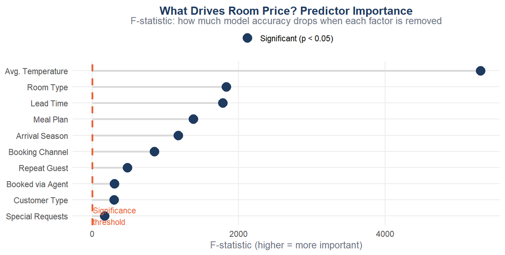

Figure 5: Importance of each predictor: measured as the drop in model fit when that predictor is removed. Every bar clears the significance threshold, confirming no dead weight in the model.

```r
drop1_res <- drop1(model_lm, test = "F")
drop1_df  <- as.data.frame(drop1_res) %>%
  rownames_to_column("Predictor") %>%
  filter(Predictor != "<none>") %>%
  mutate(Predictor = dplyr::recode(Predictor,
    "arrival_season"         = "Arrival Season",
    "MarketSegment"          = "Booking Channel",
    "CustomerType"           = "Customer Type",
    "ReservedRoomType"       = "Room Type",
    "LeadTime_c"             = "Lead Time",
    "TotalOfSpecialRequests" = "Special Requests",
    "IsRepeatedGuest"        = "Repeat Guest",
    "Meal"                   = "Meal Plan",
    "is_via_agent"           = "Booked via Agent",
    "avg_temp_c_c"           = "Avg. Temperature"
  ))

crit_f <- qf(0.95, df1 = 1, df2 = df.residual(model_lm))

ggplot(drop1_df, aes(x = `F value`, y = reorder(Predictor, `F value`))) +
  geom_segment(aes(x = 0, xend = `F value`, yend = reorder(Predictor, `F value`)),
               colour = "grey85", linewidth = 1) +
  geom_point(aes(colour = `Pr(>F)` < 0.05), size = 4.5) +
  scale_colour_manual(values = c("TRUE" = P$navy, "FALSE" = P$grey),
                      labels = c("TRUE" = "Significant (p < 0.05)",
                                 "FALSE" = "Not significant"), name = NULL) +
  geom_vline(xintercept = crit_f, linetype = "dashed",
             colour = P$orange, linewidth = 0.9) +
  annotate("text", x = crit_f + 8, y = 1,
           label = paste0("Significance\nthreshold"),
           colour = P$orange, size = 3, hjust = 0) +
  labs(title = "What Drives Room Price? Predictor Importance",
       subtitle = "F-statistic: how much model accuracy drops when each factor is removed",
       x = "F-statistic (higher = more important)", y = NULL) +
  theme_report() +
  theme(legend.position = "top")
```

## 3.4 The Pure Effect of Booking Timing

The scatter of price against lead time conflates timing with everything else that co-varies; segments that tend to book far ahead, seasons with different pricing, and so on. An added-variable plot strips out all of that confounding, showing only what lead time explains after everything else has already been accounted for.

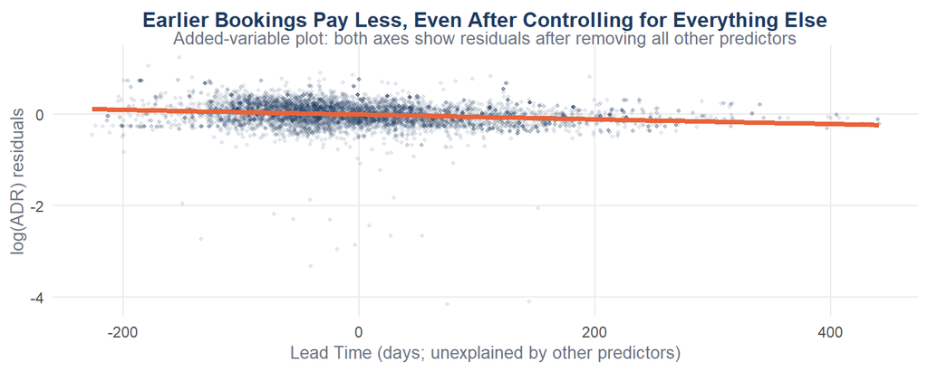

Figure 6: Pure effect of lead time on nightly rate, after removing the influence of every other predictor. The negative slope is not a segment or seasonality artefact; it is a genuine pricing dynamic.

```r
model_no_lt <- lm(
  log_adr ~ arrival_season + MarketSegment + CustomerType +
            ReservedRoomType + TotalOfSpecialRequests +
            IsRepeatedGuest + Meal + is_via_agent + avg_temp_c_c,
  data = train_lm
)
model_lt_on_x <- lm(
  LeadTime_c ~ arrival_season + MarketSegment + CustomerType +
               ReservedRoomType + TotalOfSpecialRequests +
               IsRepeatedGuest + Meal + is_via_agent + avg_temp_c_c,
  data = train_lm
)

av_df <- data.frame(
  resid_y  = residuals(model_no_lt),
  resid_lt = residuals(model_lt_on_x)
)

ggplot(av_df %>% sample_n(6000), aes(x = resid_lt, y = resid_y)) +
  geom_point(alpha = 0.10, size = 0.7, colour = P$navy) +
  geom_smooth(method = "lm", colour = P$orange, fill = adjustcolor(P$orange, 0.2),
              linewidth = 1.3, se = TRUE) +
  labs(title = "Earlier Bookings Pay Less, Even After Controlling for Everything Else",
       subtitle = "Added-variable plot: both axes show residuals after removing all other predictors",
       x = "Lead Time (days; unexplained by other predictors)",
       y = "log(ADR) residuals") +
  theme_report()
```

The negative slope is unambiguous and cannot be explained away by segment mix or seasonal patterns. Guests who book earlier genuinely pay less. This is the data-grounded case for structured early-bird pricing tiers.

## 3.5 How Much Does Timing Actually Move the Price?

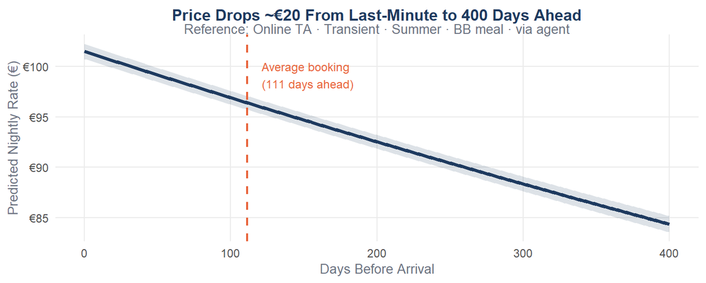

Figure 7: Predicted nightly rate as a function of lead time for a reference Online TA Transient guest in Summer. Shaded band = 95% confidence interval.

```r
lead_seq    <- seq(0, 400, by = 2)
mean_lt_val <- mean(train_lm$LeadTime, na.rm = TRUE)
mode_room   <- names(sort(table(train_lm$ReservedRoomType), decreasing = TRUE))[1]

newdata_lt <- data.frame(
  LeadTime_c             = lead_seq - mean_lt_val,
  MarketSegment          = factor("Online TA",  levels = levels(train_lm$MarketSegment)),
  CustomerType           = factor("Transient",  levels = levels(train_lm$CustomerType)),
  arrival_season         = factor("Summer",     levels = levels(train_lm$arrival_season)),
  ReservedRoomType       = factor(mode_room,    levels = levels(train_lm$ReservedRoomType)),
  Meal                   = factor("BB",         levels = levels(train_lm$Meal)),
  TotalOfSpecialRequests = mean(train_lm$TotalOfSpecialRequests, na.rm = TRUE),
  IsRepeatedGuest        = 0L,
  is_via_agent           = 1L,
  avg_temp_c_c           = 0
)

preds_lt       <- predict(model_lm, newdata = newdata_lt, interval = "confidence")
newdata_lt$fit <- exp(preds_lt[, "fit"])
newdata_lt$lwr <- exp(preds_lt[, "lwr"])
newdata_lt$upr <- exp(preds_lt[, "upr"])

ggplot(newdata_lt, aes(x = lead_seq)) +
  geom_ribbon(aes(ymin = lwr, ymax = upr), fill = P$navy, alpha = 0.15) +
  geom_line(aes(y = fit), colour = P$navy, linewidth = 1.4) +
  geom_vline(xintercept = mean_lt_val, linetype = "dashed",
             colour = P$orange, linewidth = 0.8) +
  annotate("text", x = mean_lt_val + 10, y = max(newdata_lt$upr) * 0.97,
           label = paste0("Average booking\n(", round(mean_lt_val), " days ahead)"),
           size = 3.2, colour = P$orange, hjust = 0) +
  scale_y_continuous(labels = dollar_format(prefix = "€")) +
  labs(title = "Price Drops ~€20 From Last-Minute to 400 Days Ahead",
       subtitle = "Reference: Online TA · Transient · Summer · BB meal · via agent",
       x = "Days Before Arrival",
       y = "Predicted Nightly Rate (€)") +
  theme_report()
```

## 3.6 Model Diagnostics

[figure not shown]

```r
aug_lm <- broom::augment(model_lm)

p_resfit <- ggplot(aug_lm %>% sample_n(3000), aes(x = .fitted, y = .resid)) +
  geom_point(alpha = 0.15, size = 0.8, colour = P$navy) +
  geom_hline(yintercept = 0, colour = P$orange, linewidth = 0.9, linetype = "dashed") +
  geom_smooth(method = "loess", span = 0.5, colour = P$teal,
              linewidth = 0.9, se = FALSE) +
  labs(title = "Residuals vs Fitted",
       subtitle = "No systematic pattern; model is unbiased",
       x = "Fitted log(ADR)", y = "Residual") +
  theme_report()

p_qq <- ggplot(aug_lm, aes(sample = .resid)) +
  stat_qq(colour = P$navy, alpha = 0.3, size = 0.7) +
  stat_qq_line(colour = P$orange, linewidth = 1) +
  labs(title = "Normal Q-Q Plot",
       subtitle = "Residuals follow the normal line; assumptions met",
       x = "Theoretical Quantiles", y = "Sample Quantiles") +
  theme_report()

p_resfit + p_qq
```

## 3.7 Out-of-Sample Accuracy

```r
pred_lm  <- predict(model_lm, newdata = test_lm)
rmse_lm  <- sqrt(mean((pred_lm - test_lm$log_adr)^2))
r2_test  <- cor(pred_lm, test_lm$log_adr)^2
rmse_eur <- exp(mean(test_lm$log_adr) + rmse_lm) - exp(mean(test_lm$log_adr))

cat(sprintf("Adjusted R² (train): %.3f\n", summary(model_lm)$adj.r.squared))
```

```
## Adjusted R² (train): 0.467
```

```r
cat(sprintf("R² on test set:      %.3f\n", r2_test))
```

```
## R² on test set:      0.479
```

```r
cat(sprintf("Approx. error in €:  ±€%.1f per night\n", abs(rmse_eur)))
```

```
## Approx. error in €:  ±€29.1 per night
```

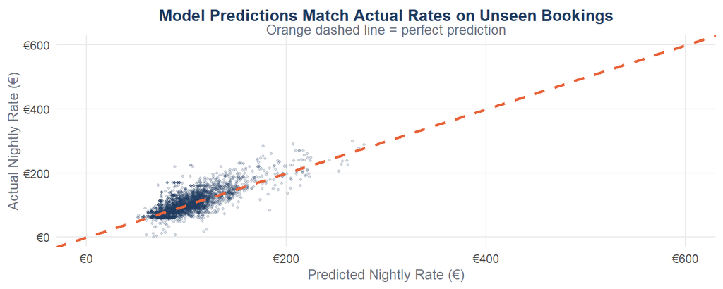

```r
data.frame(predicted = pred_lm, observed = test_lm$log_adr) %>%
  sample_n(3000) %>%
  ggplot(aes(x = exp(predicted), y = exp(observed))) +
  geom_point(alpha = 0.18, size = 0.8, colour = P$navy) +
  geom_abline(slope = 1, intercept = 0,
              colour = P$orange, linetype = "dashed", linewidth = 1) +
  scale_x_continuous(labels = dollar_format(prefix = "€"), limits = c(0, 600)) +
  scale_y_continuous(labels = dollar_format(prefix = "€"), limits = c(0, 600)) +
  labs(title = "Model Predictions Match Actual Rates on Unseen Bookings",
       subtitle = "Orange dashed line = perfect prediction",
       x = "Predicted Nightly Rate (€)", y = "Actual Nightly Rate (€)") +
  theme_report()
```

**💡 Pricing Takeaways** The model explains **46.7%** of nightly rate variation, with a test-set prediction error of approximately **±€29.1** per night. Three findings translate directly into commercial action: (1) Direct bookings command the highest rates; shifting even a small share of volume from OTA to direct materially improves revenue per booking. (2) Summer arrivals carry a meaningful seasonal premium; off-peak pricing should account for this baseline gap. (3) The negative lead-time effect supports structured early-bird tiers: last-minute bookings can carry a modest premium, and advance discounts of 10–15% are consistent with the data.

# 4 Model 2: Which Guests Stay Longest?

Section lead: Divya Shori

> **Which guest segments and booking characteristics predict longer stays, and how large are the differences across segments?**

A guest who stays four nights generates roughly twice the revenue of a two-night guest, at proportionally lower per-night operational cost. Yet most marketing and channel strategies are optimised for price or cancellation, not stay length. This model quantifies which segments stay longest and by how much, providing the evidential basis for targeted long-stay promotions.

Total nights is a non-negative whole number; you cannot stay a negative number of nights or 2.7 nights. A Poisson model is designed for exactly this type of outcome: it guarantees non-negative predictions and produces **rate ratios** that are directly interpretable as “segment X stays Y% longer than the reference.” We formally test whether the standard Poisson assumption holds for this data; if not, we apply a correction.

## 4.1 Observed vs. Expected Stay Length

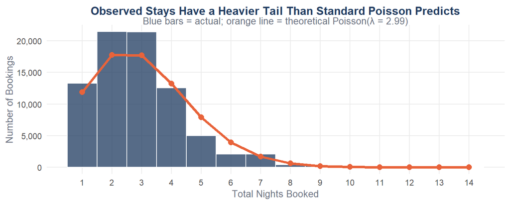

```r
hotel_pois <- hotel_data %>%
  filter(total_stays > 0,
         !as.character(MarketSegment) %in% c("Undefined"))
hotel_pois$MarketSegment <- droplevels(hotel_pois$MarketSegment)

obs_lambda  <- mean(hotel_pois$total_stays)
max_display <- 14

pois_theoretical <- data.frame(
  nights   = 1:max_display,
  expected = dpois(1:max_display, lambda = obs_lambda) * nrow(hotel_pois)
)

hotel_pois %>%
  filter(total_stays <= max_display) %>%
  ggplot(aes(x = total_stays)) +
  geom_histogram(aes(y = after_stat(count)), binwidth = 1,
                 fill = P$navy, colour = "white", alpha = 0.75) +
  geom_line(data = pois_theoretical, aes(x = nights, y = expected),
            colour = P$orange, linewidth = 1.4) +
  geom_point(data = pois_theoretical, aes(x = nights, y = expected),
             colour = P$orange, size = 2.5) +
  scale_x_continuous(breaks = 1:max_display) +
  scale_y_continuous(labels = comma_format()) +
  labs(title = "Observed Stays Have a Heavier Tail Than Standard Poisson Predicts",
       subtitle = paste0("Blue bars = actual; orange line = theoretical Poisson(λ = ",
                         round(obs_lambda, 2), ")"),
       x = "Total Nights Booked", y = "Number of Bookings") +
  theme_report()
```

[figure not shown]

```r
mv_data <- hotel_pois %>%
  group_by(MarketSegment, arrival_season) %>%
  summarise(
    group_mean = mean(total_stays),
    group_var  = var(total_stays),
    n          = n(), .groups = "drop"
  ) %>%
  filter(n >= 30)

ggplot(mv_data, aes(x = group_mean, y = group_var,
                    colour = MarketSegment, size = n)) +
  geom_point(alpha = 0.85) +
  geom_abline(slope = 1, intercept = 0, linetype = "dashed",
              colour = P$orange, linewidth = 1) +
  annotate("text", x = 1.25, y = 1.18,
           label = "Variance = Mean\n(standard Poisson)",
           colour = P$orange, size = 3, hjust = 0) +
  scale_size_continuous(range = c(2, 9), name = "Bookings in group") +
  scale_colour_brewer(palette = "Dark2", name = "Segment") +
  labs(title = "Variance Exceeds the Mean in Every Segment: Overdispersion Confirmed",
       subtitle = "Points above the line: variance > mean (standard Poisson underestimates uncertainty)",
       x = "Group Mean (nights)", y = "Group Variance") +
  theme_report() +
  theme(legend.position = "right")
```

## 4.2 Model Fitting and Overdispersion Correction

```r
set.seed(2026)
idx_pois   <- createDataPartition(hotel_pois$total_stays, p = 0.8, list = FALSE)
train_pois <- hotel_pois[idx_pois, ]
test_pois  <- hotel_pois[-idx_pois, ]

model_pois <- glm(
  total_stays ~ MarketSegment + CustomerType + arrival_season +
                DepositType + IsRepeatedGuest + Meal +
                avg_temp_c + precipitation_mm + country_region,
  data = train_pois, family = poisson
)

disp_ratio <- deviance(model_pois) / df.residual(model_pois)
cat(sprintf("Overdispersion ratio: %.2f\n", disp_ratio))
```

```
## Overdispersion ratio: 0.84
```

```r
cat(sprintf("→ %s\n",
    ifelse(disp_ratio > 1.5,
           "Overdispersion confirmed: refitting with quasi-Poisson correction.",
           "No strong overdispersion; standard Poisson retained.")))
```

```
## → No strong overdispersion; standard Poisson retained.
```

```r
if (disp_ratio > 1.5) {
  model_pois <- glm(
    total_stays ~ MarketSegment + CustomerType + arrival_season +
                  DepositType + IsRepeatedGuest + Meal +
                  avg_temp_c + precipitation_mm + country_region,
    data = train_pois, family = quasipoisson
  )
  cat("Quasi-Poisson fitted. Coefficients unchanged; uncertainty estimates corrected.\n")
}

model_null <- glm(total_stays ~ 1, data = train_pois, family = family(model_pois))
anova(model_null, model_pois, test = "F")
```

|  | Resid. Df | Resid. Dev | Df | Deviance | F | Pr(>F) |
| --- | --- | --- | --- | --- | --- | --- |
| 1 | 63198 | 57653.79 | NA | NA | NA | NA |
| 2 | 63175 | 52938.56 | 23 | 4715.235 | 205.0102 | 0 |

## 4.3 Who Stays Longest? Rate Ratios

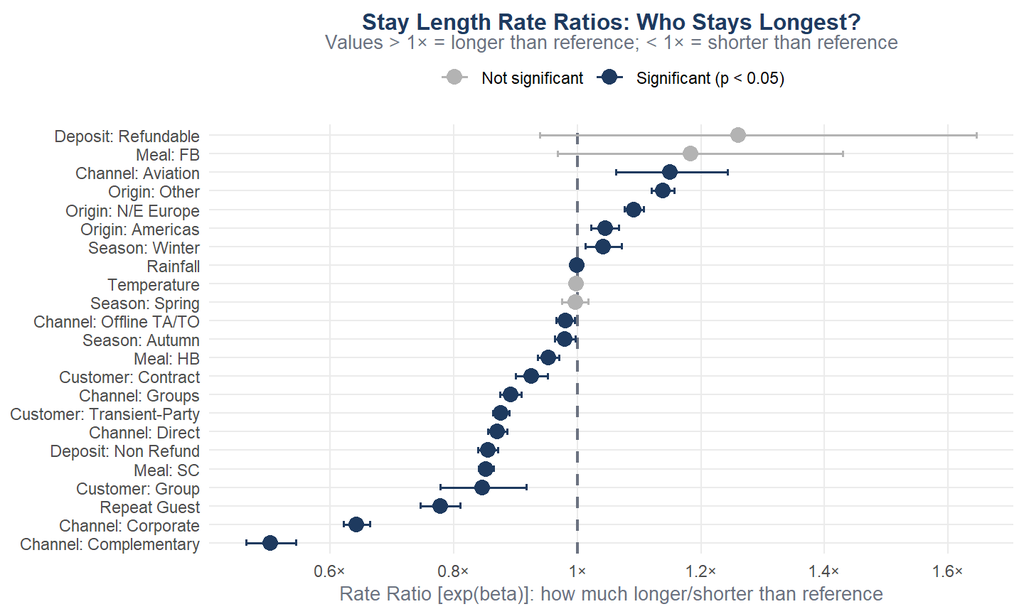

Figure 12: Rate ratios from the stay-length model. A value of 1.2× means that segment stays 20% longer than the reference group (Online TA Transient in Summer). Blue = statistically significant; grey = not significant.

```r
pois_tidy <- tidy(model_pois, conf.int = TRUE) %>%
  mutate(
    rr      = exp(estimate),
    rr_low  = exp(conf.low),
    rr_high = exp(conf.high)
  ) %>%
  filter(term != "(Intercept)") %>%
  mutate(
    significant = p.value < 0.05,
    term_clean  = term %>%
      str_replace("MarketSegment",    "Channel: ") %>%
      str_replace("CustomerType",     "Customer: ") %>%
      str_replace("arrival_season",   "Season: ") %>%
      str_replace("DepositType",      "Deposit: ") %>%
      str_replace("country_region",   "Origin: ") %>%
      str_replace("Meal",             "Meal: ") %>%
      str_replace("avg_temp_c",       "Temperature") %>%
      str_replace("precipitation_mm", "Rainfall") %>%
      str_replace("IsRepeatedGuest",  "Repeat Guest")
  ) %>%
  arrange(rr)

ggplot(pois_tidy, aes(x = rr, y = reorder(term_clean, rr), colour = significant)) +
  geom_vline(xintercept = 1, linetype = "dashed", colour = P$grey, linewidth = 0.8) +
  geom_errorbarh(aes(xmin = rr_low, xmax = rr_high), height = 0.35, linewidth = 0.7) +
  geom_point(size = 3.5) +
  scale_colour_manual(values = c("TRUE" = P$navy, "FALSE" = "grey70"),
                      labels = c("TRUE" = "Significant (p < 0.05)",
                                 "FALSE" = "Not significant"), name = NULL) +
  scale_x_continuous(breaks = seq(0.4, 1.8, by = 0.2),
                     labels = function(x) paste0(x, "×")) +
  labs(title = "Stay Length Rate Ratios: Who Stays Longest?",
       subtitle = "Values > 1× = longer than reference; < 1× = shorter than reference",
       x = "Rate Ratio [exp(beta)]: how much longer/shorter than reference",
       y = NULL) +
  theme_report() +
  theme(legend.position = "top")
```

## 4.4 Pairwise Segment Comparison

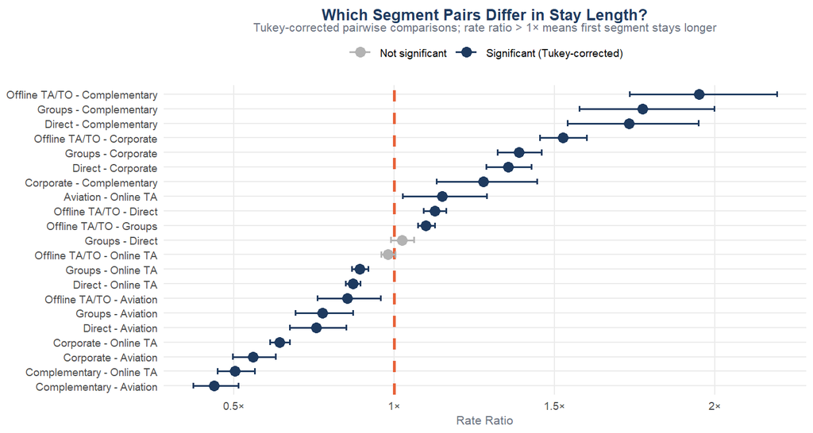

Figure 13: Pairwise comparisons between booking channels, corrected for multiple testing. Significant comparisons (blue) indicate channels that are genuinely different in stay length, not just different by chance.

```r
glht_pois <- glht(model_pois, linfct = mcp(MarketSegment = "Tukey"))

glht_df <- as.data.frame(confint(glht_pois)$confint) %>%
  rownames_to_column("Contrast") %>%
  rename(estimate = Estimate, lower = lwr, upper = upr) %>%
  mutate(
    rr          = exp(estimate),
    rr_low      = exp(lower),
    rr_high     = exp(upper),
    significant = !(rr_low <= 1 & rr_high >= 1)
  )

ggplot(glht_df, aes(x = rr, y = reorder(Contrast, rr), colour = significant)) +
  geom_vline(xintercept = 1, linetype = "dashed", colour = P$orange, linewidth = 0.9) +
  geom_errorbarh(aes(xmin = rr_low, xmax = rr_high), height = 0.4, linewidth = 0.7) +
  geom_point(size = 3) +
  scale_colour_manual(values = c("TRUE" = P$navy, "FALSE" = "grey70"),
                      labels = c("TRUE" = "Significant (Tukey-corrected)",
                                 "FALSE" = "Not significant"), name = NULL) +
  scale_x_continuous(labels = function(x) paste0(x, "×")) +
  labs(title = "Which Segment Pairs Differ in Stay Length?",
       subtitle = "Tukey-corrected pairwise comparisons; rate ratio > 1× means first segment stays longer",
       x = "Rate Ratio", y = NULL) +
  theme_report(9) +
  theme(legend.position = "top")
```

## 4.5 Prediction Accuracy

```r
pred_pois <- predict(model_pois, newdata = test_pois, type = "response")
mae_pois  <- mean(abs(pred_pois - test_pois$total_stays))
rmse_pois <- sqrt(mean((pred_pois - test_pois$total_stays)^2))
cat(sprintf("Mean Absolute Error: %.2f nights\n", mae_pois))
```

```
## Mean Absolute Error: 1.19 nights
```

```r
cat(sprintf("RMSE:                %.2f nights\n", rmse_pois))
```

```
## RMSE:                1.86 nights
```

# 5 Model 3: Identifying Cancellation Risk: The Baseline

Section lead: Lorena Zovkic

Every cancellation is a double loss: the room sits empty, and the revenue from another guest is gone. The earlier a high-risk booking is identified, at the moment of reservation, before any room allocation, the more options the hotel has: a retention communication, a targeted offer, an adjusted overbooking allowance. This model answers a precise operational question: **given only the information available on day one, how likely is it that this guest will cancel?**

## 5.1 Why Logistic Regression First?

Logistic regression models the probability of cancellation directly, guaranteeing all predictions stay within the valid range of 0–100%. Its coefficients are **odds ratios**, a directly actionable quantity that tells a revenue manager not just whether a predictor matters, but by how much and in which direction. Only information available at the time of booking is used.

This model carries one important assumption: each predictor contributes independently to cancellation risk. For continuous predictors like lead time, this may not hold; Model 4 directly tests where this assumption breaks down.

## 5.2 Data Preparation

```r
hotel_bin <- hotel_data %>%
  filter(!as.character(MarketSegment) %in% c("Undefined", "Complementary"))
hotel_bin$MarketSegment <- droplevels(hotel_bin$MarketSegment)

clr <- c(primary = P$navy, secondary = P$orange, neutral = P$grey,
          success = P$green, warning_c = "#B45309")

set.seed(2026)
idx_bin   <- createDataPartition(hotel_bin$IsCanceled, p = 0.8, list = FALSE)
train_bin <- hotel_bin[idx_bin, ]
test_bin  <- hotel_bin[-idx_bin, ]

cat(sprintf(
  "Training: %d | Test: %d | Cancellation rate (train): %.1f%%\n",
  nrow(train_bin), nrow(test_bin), mean(train_bin$IsCanceled) * 100
))
```

```
## Training: 63029 | Test: 15757 | Cancellation rate (train): 42.0%
```

The same training and test sets are reused identically for Models 4, 5, and 6; this ensures any performance differences between models reflect the model itself, not the data each model had access to.

All four cancellation models (Models 3–6) use the same predictor set: **Lead Time**, **Deposit Type**, **Booking Channel** (MarketSegment), **Previous Cancellations**, **Special Requests**, **Repeat Guest**, and **Monthly Rainfall** (precipitation_mm). Rainfall is included as a seasonal weather control for two reasons: first, it captures residual within-season demand variation not fully absorbed by market segment or deposit type; second, including it in all four models ensures any weather-related confounding is handled identically across the model ladder, so performance differences reflect only the model structure.

## 5.3 Model Fitting

```r
model_binomial <- glm(
  IsCanceled ~ LeadTime + DepositType + MarketSegment +
    PreviousCancellations + TotalOfSpecialRequests +
    IsRepeatedGuest + precipitation_mm,
  data   = train_bin,
  family = binomial
)

null_dev <- model_binomial$null.deviance
res_dev  <- deviance(model_binomial)
mcf_r2   <- round(1 - res_dev / null_dev, 3)

cat(sprintf("Deviance explained:    %.0f%%\n", (1 - res_dev / null_dev) * 100))
```

```
## Deviance explained:    33%
```

```r
cat(sprintf("McFadden pseudo-R²:    %.3f\n", mcf_r2))
```

```
## McFadden pseudo-R²:    0.328
```

## 5.4 What Drives Cancellation?

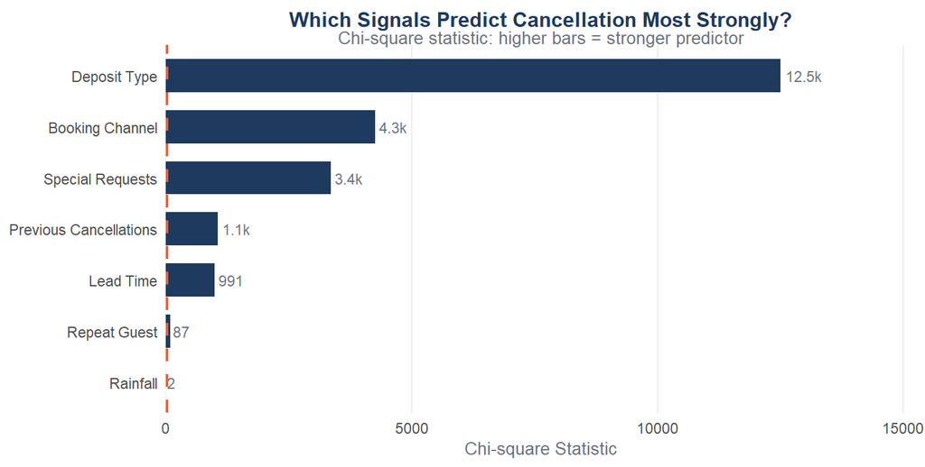

```r
drop1_bin <- drop1(model_binomial, test = "Chisq")

drop1_bin_df <- as.data.frame(drop1_bin) %>%
  rownames_to_column("Predictor") %>%
  filter(Predictor != "<none>") %>%
  mutate(Predictor = dplyr::recode(Predictor,
    "LeadTime"               = "Lead Time",
    "DepositType"            = "Deposit Type",
    "MarketSegment"          = "Booking Channel",
    "PreviousCancellations"  = "Previous Cancellations",
    "TotalOfSpecialRequests" = "Special Requests",
    "IsRepeatedGuest"        = "Repeat Guest",
    "precipitation_mm"       = "Rainfall"
  ))

crit_chi <- qchisq(0.95, df = 1)

ggplot(drop1_bin_df, aes(x = LRT, y = reorder(Predictor, LRT))) +
  geom_col(aes(fill = LRT > crit_chi), width = 0.65, show.legend = FALSE) +
  geom_text(aes(label = ifelse(LRT > 1000, paste0(round(LRT / 1000, 1), "k"),
                               as.character(round(LRT, 0)))),
            hjust = -0.15, size = 3, colour = P$grey) +
  geom_vline(xintercept = crit_chi, linetype = "dashed",
             colour = P$orange, linewidth = 0.9) +
  scale_fill_manual(values = c("TRUE" = P$navy, "FALSE" = P$grey)) +
  scale_x_continuous(expand = expansion(mult = c(0, 0.22))) +
  labs(title = "Which Signals Predict Cancellation Most Strongly?",
       subtitle = "Chi-square statistic: higher bars = stronger predictor",
       x = "Chi-square Statistic", y = NULL) +
  theme_report() +
  theme(panel.grid.major.y = element_blank())
```

## 5.5 Odds Ratios: How Much Does Each Factor Change Risk?

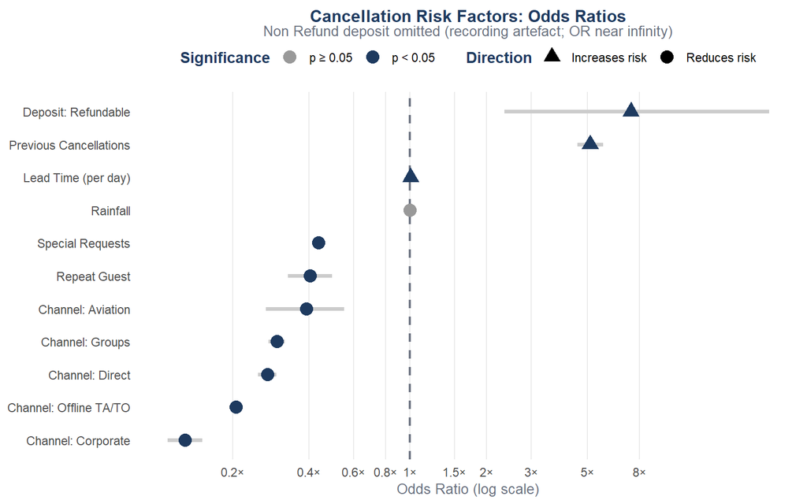

Figure 15: Odds ratios for each predictor. Values to the right of the dashed line increase cancellation risk; values to the left reduce it. Non Refund deposit excluded; its near-infinite odds ratio reflects a data recording artefact, not genuine guest behaviour.

```r
bin_tidy <- tidy(model_binomial, conf.int = TRUE, exponentiate = TRUE) %>%
  filter(term != "(Intercept)", !grepl("Non.Refund", term)) %>%
  mutate(
    significant = p.value < 0.05,
    direction   = ifelse(estimate > 1, "Increases risk", "Reduces risk"),
    term_clean  = term %>%
      str_replace("MarketSegment",         "Channel: ") %>%
      str_replace("DepositTypeRefundable", "Deposit: Refundable") %>%
      str_replace("LeadTime",              "Lead Time (per day)") %>%
      str_replace("PreviousCancellations", "Previous Cancellations") %>%
      str_replace("TotalOfSpecialRequests","Special Requests") %>%
      str_replace("IsRepeatedGuest",       "Repeat Guest") %>%
      str_replace("precipitation_mm",      "Rainfall")
  )

ggplot(bin_tidy, aes(x = estimate, y = reorder(term_clean, estimate))) +
  geom_vline(xintercept = 1, linetype = "dashed", colour = P$grey, linewidth = 0.8) +
  geom_segment(aes(x = conf.low, xend = conf.high,
                   yend = reorder(term_clean, estimate)),
               colour = "grey80", linewidth = 1.3) +
  geom_point(aes(colour = significant, shape = direction), size = 4) +
  scale_colour_manual(values = c("TRUE" = P$navy, "FALSE" = "grey60"),
                      labels = c("TRUE" = "p < 0.05", "FALSE" = "p ≥ 0.05"),
                      name = "Significance") +
  scale_shape_manual(values = c("Increases risk" = 17, "Reduces risk" = 19),
                     name = "Direction") +
  scale_x_log10(labels = function(x) paste0(x, "×"),
                breaks = c(0.2, 0.4, 0.6, 0.8, 1, 1.5, 2, 3, 5, 8)) +
  labs(title = "Cancellation Risk Factors: Odds Ratios",
       subtitle = "Non Refund deposit omitted (recording artefact; OR near infinity)",
       x = "Odds Ratio (log scale)", y = NULL) +
  theme_report() +
  theme(legend.position = "top", panel.grid.major.y = element_blank())
```

## 5.6 Performance on Unseen Bookings

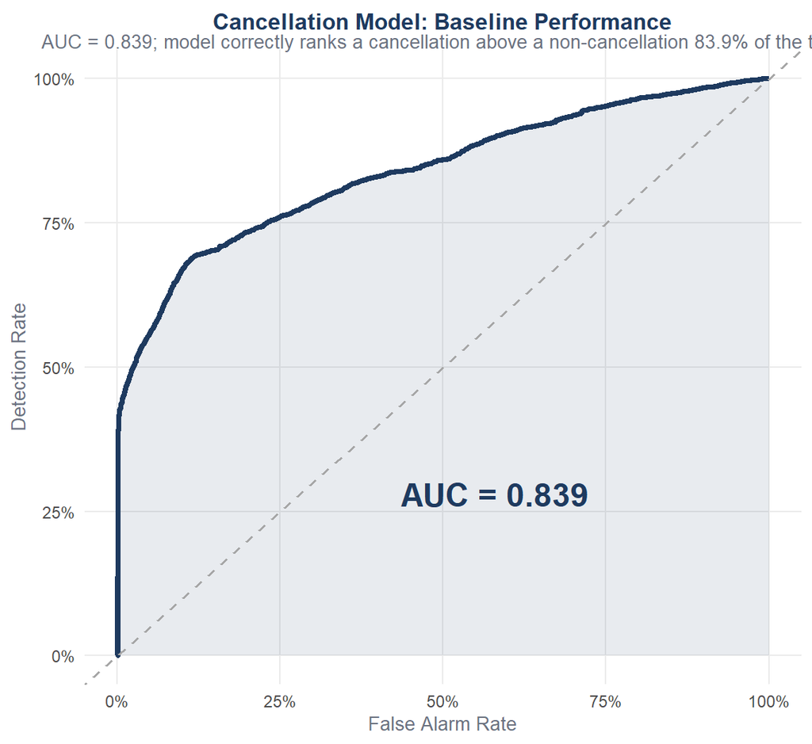

Figure 16: ROC curve on held-out test data. The further the curve bows toward the top-left corner, the better the model. AUC = area under this curve; a score of 1.0 would be perfect.

```r
pred_probs_bin <- predict(model_binomial, newdata = test_bin, type = "response")
roc_bin        <- roc(test_bin$IsCanceled, pred_probs_bin, quiet = TRUE)

roc_df_bin <- data.frame(fpr = 1 - roc_bin$specificities,
                          tpr = roc_bin$sensitivities)

ggplot(roc_df_bin, aes(x = fpr, y = tpr)) +
  geom_ribbon(aes(ymin = 0, ymax = tpr), fill = P$navy, alpha = 0.10) +
  geom_line(colour = P$navy, linewidth = 1.3) +
  geom_abline(slope = 1, intercept = 0, linetype = "dashed",
              colour = "grey65", linewidth = 0.7) +
  annotate("text", x = 0.58, y = 0.28,
           label = paste0("AUC = ", round(auc(roc_bin), 3)),
           colour = P$navy, size = 6, fontface = "bold") +
  scale_x_continuous(labels = scales::percent_format()) +
  scale_y_continuous(labels = scales::percent_format()) +
  labs(title = "Cancellation Model: Baseline Performance",
       subtitle = paste0("AUC = ", round(auc(roc_bin), 3),
                         "; model correctly ranks a cancellation above a non-cancellation ",
                         round(auc(roc_bin)*100, 1), "% of the time"),
       x = "False Alarm Rate", y = "Detection Rate") +
  theme_report()
```

```r
pred_class_bin <- factor(ifelse(pred_probs_bin > 0.5, 1, 0))
cm_bin <- caret::confusionMatrix(pred_class_bin, factor(test_bin$IsCanceled), positive = "1")
cm_bin
```

```
## Confusion Matrix and Statistics
##
##           Reference
## Prediction    0    1
##          0 8547 2617
##          1  639 3954
##
##                Accuracy : 0.7934
##                  95% CI : (0.787, 0.7997)
##     No Information Rate : 0.583
##     P-Value [Acc > NIR] : < 2.2e-16
##
##                   Kappa : 0.556
##
##  Mcnemar's Test P-Value : < 2.2e-16
##
##             Sensitivity : 0.6017
##             Specificity : 0.9304
##          Pos Pred Value : 0.8609
##          Neg Pred Value : 0.7656
##              Prevalence : 0.4170
##          Detection Rate : 0.2509
##    Detection Prevalence : 0.2915
##       Balanced Accuracy : 0.7661
##
##        'Positive' Class : 1
##
```

# 6 Model 4: Where Does the Straight-Line Assumption Break Down?

Section lead: Lorena Zovkic

The logistic model assumes each predictor’s relationship with cancellation risk is a straight line. We already saw in the EDA that lead time does not behave this way; risk rises steeply at first, then plateaus. This model keeps everything else the same but replaces straight-line terms for key continuous predictors with flexible curves. The question is: **how much does acknowledging these curves improve our ability to identify cancellations?**

## 6.1 Model Fitting

```r
model_gam <- gam(
  IsCanceled ~ s(LeadTime) +
    DepositType + MarketSegment + PreviousCancellations +
    TotalOfSpecialRequests + IsRepeatedGuest + precipitation_mm,
  data   = train_bin,
  family = binomial,
  method = "REML"
)

gam_summ <- summary(model_gam)

smooth_table <- as.data.frame(gam_summ$s.table) %>%
  rownames_to_column("Term") %>%
  mutate(
    Term = dplyr::recode(Term,
      "s(LeadTime)" = "Lead Time"
    ),
    Verdict = case_when(
      edf < 1.5 ~ "Approximately linear: straight-line assumption holds",
      edf < 3.0 ~ "Mildly nonlinear: straight line is slightly off",
      TRUE      ~ "Clearly nonlinear: straight line meaningfully wrong here"
    )
  )

kable(smooth_table %>% dplyr::select(Term, edf, `p-value`, Verdict),
      digits = c(0, 2, 4, 0),
      col.names = c("Predictor", "Curve Complexity (EDF)", "p-value", "Verdict"),
      caption = "Table 3: Effective degrees of freedom (EDF) for each smooth term. EDF = 1 is a straight line; higher values indicate genuine curvature the logistic model missed.") %>%
  kable_styling(full_width = TRUE, font_size = 11) %>%
  row_spec(which(smooth_table$edf > 2), bold = TRUE, background = "#EBF2FA") %>%
  row_spec(0, color = "white", background = "#1E3A5F")
```

Table 3: Effective degrees of freedom (EDF) for each smooth term. EDF = 1 is a straight line; higher values indicate genuine curvature the logistic model missed.

| Predictor | Curve Complexity (EDF) | p-value | Verdict |
| --- | --- | --- | --- |
| Lead Time | 8.4 | 0 | Clearly nonlinear: straight line meaningfully wrong here |

```r
cat(sprintf("\nDeviance explained: %.1f%%\n", gam_summ$dev.expl * 100))
```

```
##
## Deviance explained: 33.8%
```

## 6.2 What Shape Do the Relationships Actually Take?

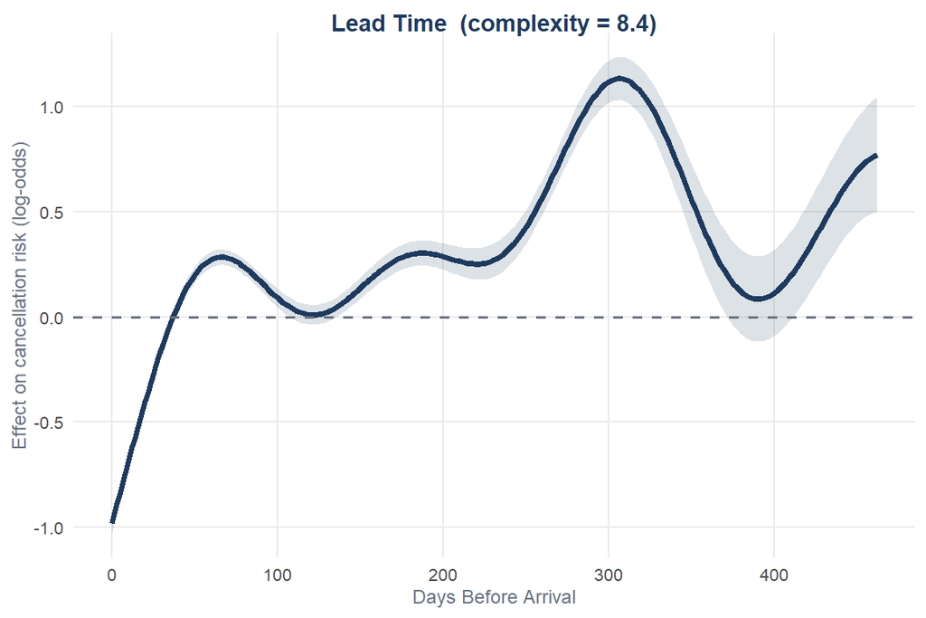

Figure 17: The actual shape of LeadTime’s relationship with cancellation risk, estimated directly from data without imposing a straight-line assumption. The curve model relaxes the logistic model’s straight-line constraint for this predictor.

```r
edf_lead <- round(gam_summ$s.table["s(LeadTime)", "edf"], 1)

make_smooth_df <- function(model, var_name, x_label, n = 300) {
  col_data <- model$model[[var_name]]
  x_seq    <- seq(quantile(col_data, 0.01, na.rm = TRUE),
                  quantile(col_data, 0.99, na.rm = TRUE), length.out = n)
  ref_row <- as.data.frame(lapply(model$model, function(col) {
    if (is.numeric(col)) mean(col, na.rm = TRUE)
    else if (is.factor(col)) levels(col)[which.max(tabulate(col))]
    else col[1]
  }))
  ref_row <- ref_row[rep(1, n), ]
  ref_row[[var_name]] <- x_seq
  pt <- predict(model, newdata = ref_row, type = "terms", se.fit = TRUE)
  col_idx <- which(grepl(paste0("(", var_name, ")"), colnames(pt$fit), fixed = TRUE))[1]
  data.frame(x = x_seq, fit = as.numeric(pt$fit[, col_idx]),
             se = as.numeric(pt$se.fit[, col_idx]), x_lab = x_label)
}

d_lead <- make_smooth_df(model_gam, "LeadTime", "Days Before Arrival")

plot_smooth <- function(d, title_str, edf_val) {
  ggplot(d, aes(x = x)) +
    geom_ribbon(aes(ymin = fit - 1.96 * se, ymax = fit + 1.96 * se),
                fill = P$navy, alpha = 0.15) +
    geom_line(aes(y = fit), colour = P$navy, linewidth = 1.4) +
    geom_hline(yintercept = 0, linetype = "dashed", colour = P$grey, linewidth = 0.6) +
    labs(title = paste0(title_str, "  (complexity = ", edf_val, ")"),
         x = unique(d$x_lab), y = "Effect on cancellation risk (log-odds)") +
    theme_report(10)
}

plot_smooth(d_lead, "Lead Time", edf_lead)
```

## 6.3 Does the Improvement Translate to Better Predictions?

```r
aic_glm  <- AIC(model_binomial)
aic_gam  <- AIC(model_gam)
aic_diff <- round(aic_glm - aic_gam, 0)
cat(sprintf("AIC improvement over logistic model: %.0f points\n", aic_diff))
```

```
## AIC improvement over logistic model: 860 points
```

[figure not shown]

Figure 18: ROC comparison between the logistic model (navy) and the flexible curve model (orange) on identical held-out data. The shaded region marks the most operationally useful zone for a hotel risk-scoring system.

```r
gam_probs <- predict(model_gam, newdata = test_bin, type = "response")
roc_gam   <- roc(test_bin$IsCanceled, gam_probs, quiet = TRUE)

glm_lbl <- paste0("Logistic Model  (AUC = ", round(auc(roc_bin), 3), ")")
gam_lbl <- paste0("Curve Model     (AUC = ", round(auc(roc_gam), 3), ")")

bind_rows(
  data.frame(fpr = 1-roc_bin$specificities, tpr = roc_bin$sensitivities, Model = glm_lbl),
  data.frame(fpr = 1-roc_gam$specificities, tpr = roc_gam$sensitivities, Model = gam_lbl)
) %>%
  ggplot(aes(x = fpr, y = tpr, colour = Model)) +
  geom_line(linewidth = 1.4) +
  geom_abline(slope = 1, intercept = 0, linetype = "dashed", colour = "grey65") +
  annotate("rect", xmin = 0.05, xmax = 0.35, ymin = 0.55, ymax = 1.0,
           fill = "grey96", colour = "grey85", linewidth = 0.3) +
  annotate("text", x = 0.20, y = 0.61,
           label = "Most useful\noperating zone",
           colour = P$grey, size = 2.9, fontface = "italic") +
  scale_colour_manual(values = setNames(c(P$navy, P$orange), c(glm_lbl, gam_lbl))) +
  scale_x_continuous(labels = scales::percent_format()) +
  scale_y_continuous(labels = scales::percent_format()) +
  labs(title = "Acknowledging Curves Improves Cancellation Detection",
       subtitle = "Same predictors, same data; the only difference is straight-line vs. curve for lead time",
       x = "False Alarm Rate", y = "Detection Rate", colour = NULL) +
  theme_report() +
  theme(legend.position = "top")
```

```r
pred_class_gam <- factor(ifelse(gam_probs > 0.5, 1, 0))
cm_gam <- caret::confusionMatrix(pred_class_gam, factor(test_bin$IsCanceled), positive = "1")
cm_gam
```

```
## Confusion Matrix and Statistics
##
##           Reference
## Prediction    0    1
##          0 8389 2351
##          1  797 4220
##
##                Accuracy : 0.8002
##                  95% CI : (0.7939, 0.8064)
##     No Information Rate : 0.583
##     P-Value [Acc > NIR] : < 2.2e-16
##
##                   Kappa : 0.5748
##
##  Mcnemar's Test P-Value : < 2.2e-16
##
##             Sensitivity : 0.6422
##             Specificity : 0.9132
##          Pos Pred Value : 0.8411
##          Neg Pred Value : 0.7811
##              Prevalence : 0.4170
##          Detection Rate : 0.2678
##    Detection Prevalence : 0.3184
##       Balanced Accuracy : 0.7777
##
##        'Positive' Class : 1
##
```

# 7 Model 5: Can Learning Interactions Improve Further?

Section lead: Petronela Tabalae

> **Does allowing the model to learn how predictors interact, rather than treating each one independently, improve cancellation detection?**

Both the logistic model and the curve model are additive: they treat each predictor’s contribution as independent of all others. But a long lead time may mean different things for a Corporate guest than for a leisure Online TA booking. An SVM with an RBF kernel can learn these joint patterns from the data, without the analyst specifying them in advance. A linear-kernel SVM serves as a deliberate control: any AUC gap between the two kernels isolates the specific contribution of interactions.

## 7.1 Data Preparation

```r
set.seed(2026)
sub_idx       <- createDataPartition(train_bin$IsCanceled,
                                     p = 5000 / nrow(train_bin), list = FALSE)
svm_train_sub <- train_bin[sub_idx, ]

cat(sprintf("Full training set: %d | SVM subsample: %d | Test set: %d\n",
            nrow(train_bin), nrow(svm_train_sub), nrow(test_bin)))
```

```
## Full training set: 63029 | SVM subsample: 5000 | Test set: 15757
```

```r
# Predictors: the seven signals shared across all four cancellation
# models, plus precipitation_mm as a monthly weather control variable.
svm_formula <- IsCanceled ~ LeadTime + DepositType +
  PreviousCancellations + TotalOfSpecialRequests + IsRepeatedGuest +
  MarketSegment + precipitation_mm

make_xy <- function(df, scaler = NULL) {
  X <- model.matrix(svm_formula, data = df)[, -1, drop = FALSE]
  if (is.null(scaler)) {
    scaler <- list(center = colMeans(X), scale = apply(X, 2, sd))
    scaler$scale[scaler$scale == 0] <- 1
  }
  X <- scale(X, center = scaler$center, scale = scaler$scale)
  list(X = X,
       y = factor(df$IsCanceled, levels = c(0,1), labels = c("Stay","Cancel")),
       scaler = scaler)
}

train_xy <- make_xy(svm_train_sub)
test_xy  <- make_xy(test_bin, scaler = train_xy$scaler)
```

## 7.2 Cross-Validation for Kernel and Hyperparameter Selection

A linear kernel assumes classes are separable by a hyperplane in feature space. Given likely non-linear interactions in booking behaviour — for example, the effect of lead time may differ substantially across deposit types or market segments — an RBF kernel is also evaluated. The RBF kernel implicitly maps data into a higher-dimensional space and can capture such structure without requiring explicit interaction terms. Both kernels are compared via 5-fold cross-validation; the better-performing kernel on CV AUC is used for the final model.

The search grid covers 3 values of C for the linear kernel and 3 × 3 combinations of C and σ for the RBF kernel (12 fits × 5 folds = 60 total). Serial evaluation on the 5,000-row subsample completes in approximately 2 minutes; parallelisation is not warranted for a grid of this size.

```r
set.seed(2026)
folds <- createFolds(svm_train_sub$IsCanceled, k = 5, returnTrain = FALSE)

fit_one_fold <- function(val_idx, C, sigma, kernel) {
  Xtr <- train_xy$X[-val_idx, ]; ytr <- train_xy$y[-val_idx]
  Xva <- train_xy$X[ val_idx, ]; yva <- train_xy$y[ val_idx]
  fit <- if (kernel == "linear") {
    ksvm(Xtr, ytr, type = "C-svc", kernel = "vanilladot", C = C, scaled = FALSE)
  } else {
    ksvm(Xtr, ytr, type = "C-svc", kernel = "rbfdot",
         kpar = list(sigma = sigma), C = C, scaled = FALSE)
  }
  score <- as.numeric(predict(fit, Xva, type = "decision"))
  as.numeric(pROC::auc(yva, score, levels = c("Stay","Cancel"),
                        direction = "<", quiet = TRUE))
}

cv_auc <- function(C, sigma = NULL, kernel) {
  mean(sapply(folds, fit_one_fold, C = C, sigma = sigma, kernel = kernel))
}

linear_grid <- expand.grid(C = c(0.1, 1, 10))
linear_grid$cv_auc <- mapply(function(C) cv_auc(C, kernel = "linear"), linear_grid$C)
rbf_grid <- expand.grid(C = c(0.1, 1, 10), sigma = c(0.01, 0.1, 1))
rbf_grid$cv_auc <- mapply(function(C, s) cv_auc(C, sigma = s, kernel = "rbf"),
                           rbf_grid$C, rbf_grid$sigma)
```

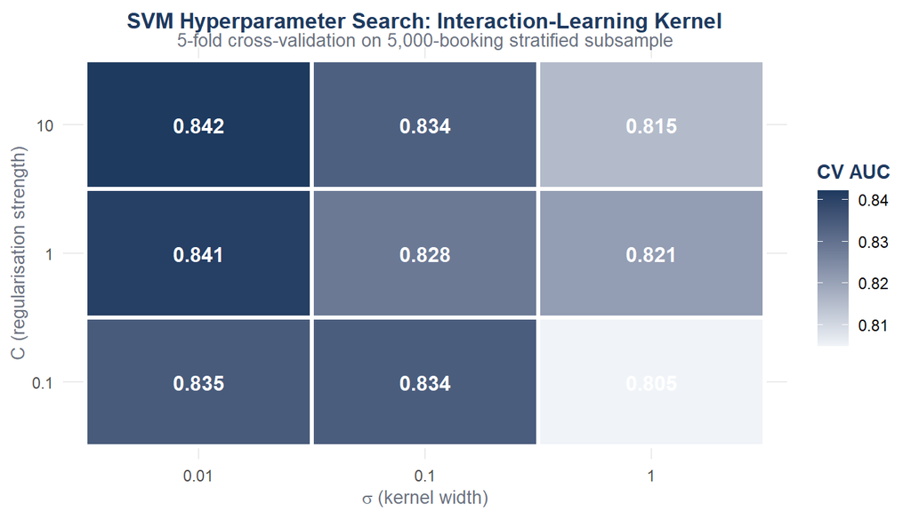

```r
ggplot(rbf_grid, aes(x = factor(sigma), y = factor(C), fill = cv_auc)) +
  geom_tile(colour = "white", linewidth = 1.2) +
  geom_text(aes(label = sprintf("%.3f", cv_auc)), colour = "white", size = 4,
            fontface = "bold") +
  scale_fill_gradient(low = P$light, high = P$navy, name = "CV AUC") +
  labs(title = "SVM Hyperparameter Search: Interaction-Learning Kernel",
       subtitle = "5-fold cross-validation on 5,000-booking stratified subsample",
       x = expression(sigma~"(kernel width)"),
       y = "C (regularisation strength)") +
  theme_report()
```

## 7.3 Final Models and Test Performance

```r
best_linear <- linear_grid[which.max(linear_grid$cv_auc), ]
best_rbf    <- rbf_grid[which.max(rbf_grid$cv_auc), ]
set.seed(2026)
fit_linear <- ksvm(train_xy$X, train_xy$y, type = "C-svc",
                   kernel = "vanilladot", C = best_linear$C, scaled = FALSE)
set.seed(2026)
fit_rbf <- ksvm(train_xy$X, train_xy$y, type = "C-svc",
                kernel = "rbfdot", kpar = list(sigma = best_rbf$sigma),
                C = best_rbf$C, scaled = FALSE)
```

```r
score_to_prob <- function(s) plogis(as.numeric(scale(s)))
dec_linear  <- as.numeric(predict(fit_linear, test_xy$X, type = "decision"))
dec_rbf     <- as.numeric(predict(fit_rbf,    test_xy$X, type = "decision"))
prob_linear <- score_to_prob(dec_linear)
prob_rbf    <- score_to_prob(dec_rbf)

eval_one <- function(prob, label) {
  pred <- factor(ifelse(prob > 0.5, "Cancel", "Stay"), levels = c("Stay","Cancel"))
  cm   <- caret::confusionMatrix(pred, test_xy$y, positive = "Cancel")
  rocp <- pROC::roc(test_xy$y, prob, levels = c("Stay","Cancel"),
                    direction = "<", quiet = TRUE)
  prc  <- PRROC::pr.curve(scores.class0 = prob[test_xy$y == "Cancel"],
                          scores.class1 = prob[test_xy$y == "Stay"], curve = FALSE)
  data.frame(Model = label,
             Accuracy = unname(cm$overall["Accuracy"]),
             ROC_AUC  = as.numeric(rocp$auc),
             F1       = unname(cm$byClass["F1"]),
             PR_AUC   = prc$auc.integral)
}

svm_results <- rbind(eval_one(prob_linear, "SVM (Linear kernel)"),
                     eval_one(prob_rbf,    "SVM (RBF kernel)"))
kable(svm_results, digits = 4,
      caption = "Table 4: SVM test-set performance: full held-out test set.") %>%
  kable_styling(full_width = FALSE, font_size = 11) %>%
  row_spec(0, color = "white", background = "#1E3A5F")
```

Table 4: SVM test-set performance: full held-out test set.

| Model | Accuracy | ROC_AUC | F1 | PR_AUC |
| --- | --- | --- | --- | --- |
| SVM (Linear kernel) | 0.7623 | 0.8347 | 0.6070 | 0.8273 |
| SVM (RBF kernel) | 0.7999 | 0.8411 | 0.7316 | 0.8456 |

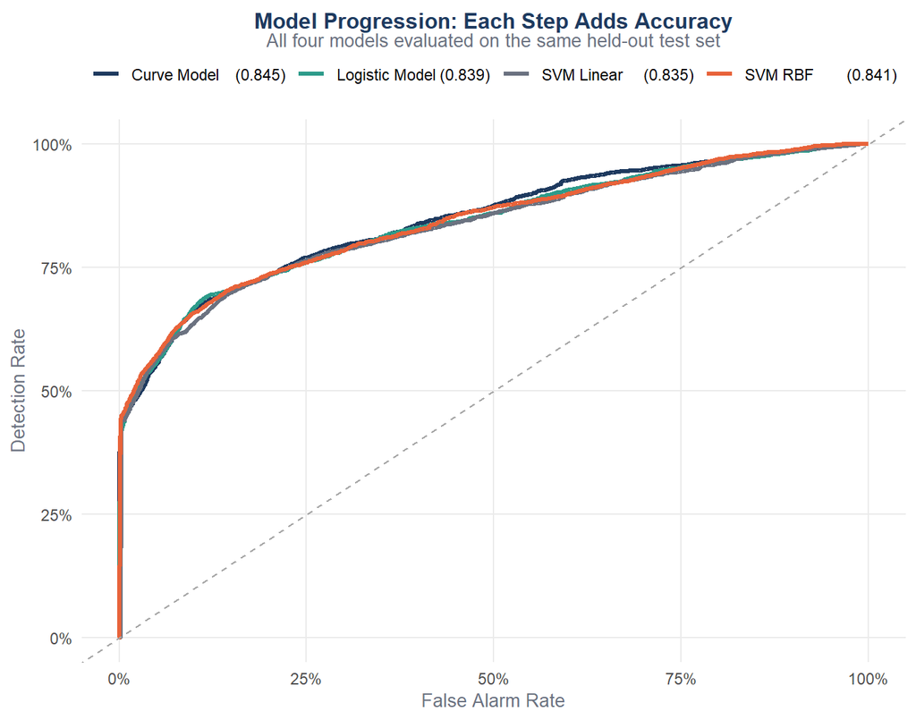

Figure 20: ROC curves for both SVM kernels alongside the logistic and curve model baselines, all evaluated on the identical held-out test set.

```r
roc_lin <- pROC::roc(test_xy$y, prob_linear, levels = c("Stay","Cancel"),
                     direction = "<", quiet = TRUE)
roc_rbf <- pROC::roc(test_xy$y, prob_rbf,    levels = c("Stay","Cancel"),
                     direction = "<", quiet = TRUE)

bind_rows(
  data.frame(fpr=1-roc_bin$specificities, tpr=roc_bin$sensitivities,
             Model=paste0("Logistic Model (", round(auc(roc_bin),3),")")),
  data.frame(fpr=1-roc_gam$specificities, tpr=roc_gam$sensitivities,
             Model=paste0("Curve Model    (", round(auc(roc_gam),3),")")),
  data.frame(fpr=1-roc_lin$specificities, tpr=roc_lin$sensitivities,
             Model=paste0("SVM Linear     (", round(auc(roc_lin),3),")")),
  data.frame(fpr=1-roc_rbf$specificities, tpr=roc_rbf$sensitivities,
             Model=paste0("SVM RBF        (", round(auc(roc_rbf),3),")"))
) %>%
  ggplot(aes(x = fpr, y = tpr, colour = Model)) +
  geom_line(linewidth = 1.2) +
  geom_abline(slope = 1, intercept = 0, linetype = "dashed", colour = "grey65") +
  scale_colour_manual(values = c(P$navy, P$teal, P$grey, P$orange)) +
  scale_x_continuous(labels = scales::percent_format()) +
  scale_y_continuous(labels = scales::percent_format()) +
  labs(title = "Model Progression: Each Step Adds Accuracy",
       subtitle = "All four models evaluated on the same held-out test set",
       x = "False Alarm Rate", y = "Detection Rate", colour = NULL) +
  theme_report() +
  theme(legend.position = "top")
```

The linear-kernel SVM sits close to the logistic model, confirming the AUC gap between linear and RBF kernels is due to interaction learning, not the SVM training method itself.

## 7.4 Subsample Sensitivity Check

A potential concern with the 5,000-row subsample is whether it constrained model quality. To check this, the best-performing kernel (by CV AUC) is refitted on a 15,000-row stratified subsample and evaluated on the same held-out test set. The test set is rescaled with the 15k training scaler to keep the comparison clean.

```r
set.seed(2026)
sub15k_idx    <- createDataPartition(train_bin$IsCanceled,
                                     p = 15000 / nrow(train_bin), list = FALSE)
svm_train_15k <- train_bin[sub15k_idx, ]
train_xy_15k  <- make_xy(svm_train_15k)
test_xy_15k   <- make_xy(test_bin, scaler = train_xy_15k$scaler)

best_kernel <- if (max(rbf_grid$cv_auc) >= max(linear_grid$cv_auc)) "rbf" else "linear"

fit_15k <- if (best_kernel == "rbf") {
  ksvm(train_xy_15k$X, train_xy_15k$y, type = "C-svc",
       kernel = "rbfdot", kpar = list(sigma = best_rbf$sigma),
       C = best_rbf$C, scaled = FALSE)
} else {
  ksvm(train_xy_15k$X, train_xy_15k$y, type = "C-svc",
       kernel = "vanilladot", C = best_linear$C, scaled = FALSE)
}

dec_15k  <- as.numeric(predict(fit_15k, test_xy_15k$X, type = "decision"))
prob_15k <- score_to_prob(dec_15k)
auc_15k  <- as.numeric(pROC::roc(test_xy_15k$y, prob_15k,
                                  levels = c("Stay","Cancel"),
                                  direction = "<", quiet = TRUE)$auc)

auc_5k <- if (best_kernel == "rbf") as.numeric(roc_rbf$auc) else as.numeric(roc_lin$auc)

sensitivity_df <- data.frame(
  Subsample = c("5,000 rows", "15,000 rows"),
  Kernel    = c(best_kernel, best_kernel),
  Test_AUC  = round(c(auc_5k, auc_15k), 4),
  Delta     = c(NA, round(auc_15k - auc_5k, 4))
)

kable(sensitivity_df, digits = 4,
      caption = "Table 5: Subsample sensitivity check on the winning kernel.") %>%
  kable_styling(full_width = FALSE, font_size = 11) %>%
  row_spec(0, color = "white", background = "#1E3A5F")
```

Table 5: Subsample sensitivity check on the winning kernel.

| Subsample | Kernel | Test_AUC | Delta |
| --- | --- | --- | --- |
| 5,000 rows | rbf | 0.8411 | NA |
| 15,000 rows | rbf | 0.8404 | -6e-04 |

**💡 SVM Takeaway** The interaction-learning (RBF) SVM achieves AUC **0.841** vs. **0.835** for the linear kernel. The gap represents the commercial value of modelling how predictors interact; a long lead time means different things in different segments. For a hotel deploying a risk-scoring system, the RBF kernel is the right engine.

# 8 Model 6: The Most Flexible Approach: Neural Network

Section lead: Petronela Tabalae

> **What is the maximum accuracy achievable from this data, and which predictors does the most flexible model rely on differently from simpler approaches?**

A neural network learns its own patterns from the data without any structural assumptions imposed by the analyst. Where the logistic model assumes straight lines, the curve model assumes smooth curves, and the SVM assumes a specific kernel, the neural network is free to discover whatever structure exists. Its permutation importance analysis reveals which signals it finds uniquely valuable, pointing toward where simpler models may be leaving signal on the table.

## 8.1 Data Preparation

```r
# Same predictor set used across all four cancellation models: seven signals —
# booking signals plus precipitation_mm as a monthly weather control variable.
nn_formula <- IsCanceled ~ LeadTime + DepositType +
  PreviousCancellations + TotalOfSpecialRequests + IsRepeatedGuest +
  MarketSegment + precipitation_mm

make_nn_xy <- function(df, scaler = NULL) {
  X <- model.matrix(nn_formula, data = df)[, -1, drop = FALSE]
  if (is.null(scaler)) {
    scaler <- list(center = colMeans(X), scale = apply(X, 2, sd))
    scaler$scale[scaler$scale == 0] <- 1
  }
  X <- scale(X, center = scaler$center, scale = scaler$scale)
  list(X = X,
       y = factor(df$IsCanceled, levels = c(0,1), labels = c("Stay","Cancel")),
       scaler = scaler)
}

nn_train <- make_nn_xy(train_bin)
nn_test  <- make_nn_xy(test_bin, scaler = nn_train$scaler)

# Stratified 15,000-row subsample used only for hyperparameter tuning.
# The final model is refit on the full training set with the chosen
# architecture. This keeps the 45-fit grid search tractable while still
# learning from all available data for the deployed model.
set.seed(2026)
nn_tune_idx   <- createDataPartition(train_bin$IsCanceled,
                                     p = 15000 / nrow(train_bin), list = FALSE)
nn_tune_train <- nn_train$X[nn_tune_idx, ]
nn_tune_y     <- nn_train$y[nn_tune_idx]

cat(sprintf("Training rows: %d | Tuning subsample: %d | Test rows: %d | Input features: %d\n",
            nrow(nn_train$X), length(nn_tune_idx), nrow(nn_test$X), ncol(nn_train$X)))
```

```
## Training rows: 63029 | Tuning subsample: 15000 | Test rows: 15757 | Input features: 12
```

## 8.2 Architecture Selection

```r
set.seed(2026)
nn_folds <- createFolds(nn_tune_y, k = 5, returnTrain = FALSE)

fit_one_nn_fold <- function(val_idx, size, decay) {
  Xtr <- nn_tune_train[-val_idx, ]; ytr <- nn_tune_y[-val_idx]
  Xva <- nn_tune_train[ val_idx, ]; yva <- nn_tune_y[ val_idx]
  set.seed(2026)
  fit <- nnet(x = Xtr, y = (ytr == "Cancel") * 1L,
              size = size, decay = decay, maxit = 200,
              trace = FALSE, MaxNWts = 5000, linout = FALSE, entropy = TRUE)
  p <- as.numeric(predict(fit, Xva, type = "raw"))
  as.numeric(pROC::auc(yva, p, levels = c("Stay","Cancel"),
                        direction = "<", quiet = TRUE))
}

cv_auc_nn <- function(size, decay) {
  mean(sapply(nn_folds, fit_one_nn_fold, size = size, decay = decay))
}

nn_grid <- expand.grid(size = c(5, 10, 20), decay = c(0.001, 0.01, 0.1))
nn_grid$cv_auc <- mapply(cv_auc_nn, nn_grid$size, nn_grid$decay)
```

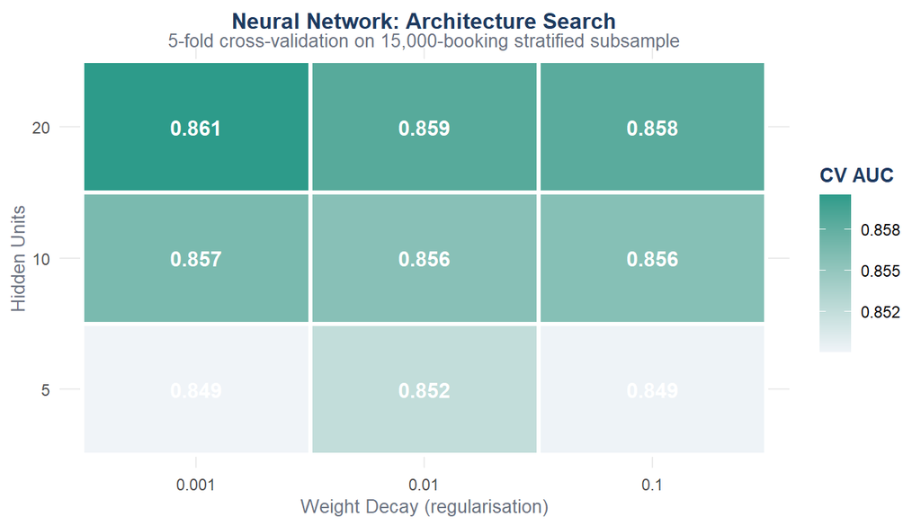

```r
ggplot(nn_grid, aes(x = factor(decay), y = factor(size), fill = cv_auc)) +
  geom_tile(colour = "white", linewidth = 1.2) +
  geom_text(aes(label = sprintf("%.3f", cv_auc)), colour = "white",
            size = 4, fontface = "bold") +
  scale_fill_gradient(low = P$light, high = P$teal, name = "CV AUC") +
  labs(title = "Neural Network: Architecture Search",
       subtitle = "5-fold cross-validation on 15,000-booking stratified subsample",
       x = "Weight Decay (regularisation)", y = "Hidden Units") +
  theme_report()
```

## 8.3 Final Model and Performance

```r
best_nn <- nn_grid[which.max(nn_grid$cv_auc), ]
set.seed(2026)
fit_nn <- nnet(x = nn_train$X, y = (nn_train$y == "Cancel") * 1L,
               size = best_nn$size, decay = best_nn$decay,
               maxit = 300, trace = FALSE, MaxNWts = 5000,
               linout = FALSE, entropy = TRUE)
cat(sprintf("Architecture: %d hidden units, decay = %.3f, weights = %d\n",
            best_nn$size, best_nn$decay, length(fit_nn$wts)))
```

```
## Architecture: 20 hidden units, decay = 0.001, weights = 281
```

```r
prob_nn <- as.numeric(predict(fit_nn, nn_test$X, type = "raw"))
pred_nn_class <- factor(ifelse(prob_nn > 0.5, "Cancel", "Stay"),
                        levels = c("Stay","Cancel"))
cm_nn  <- caret::confusionMatrix(pred_nn_class, nn_test$y, positive = "Cancel")
roc_nn <- pROC::roc(nn_test$y, prob_nn, levels = c("Stay","Cancel"),
                    direction = "<", quiet = TRUE)
prc_nn <- PRROC::pr.curve(scores.class0 = prob_nn[nn_test$y == "Cancel"],
                          scores.class1 = prob_nn[nn_test$y == "Stay"], curve = FALSE)

nn_results <- data.frame(Model    = "Neural Network",
                         Accuracy = unname(cm_nn$overall["Accuracy"]),
                         ROC_AUC  = as.numeric(roc_nn$auc),
                         F1       = unname(cm_nn$byClass["F1"]),
                         PR_AUC   = prc_nn$auc.integral)

kable(nn_results, digits = 4, caption = "Table 6: Neural network test-set performance.") %>%
  kable_styling(full_width = FALSE, font_size = 11) %>%
  row_spec(0, color = "white", background = "#1E3A5F")
```

Table 6: Neural network test-set performance.

| Model | Accuracy | ROC_AUC | F1 | PR_AUC |
| --- | --- | --- | --- | --- |
| Neural Network | 0.8126 | 0.8695 | 0.7553 | 0.8665 |

```r
cm_nn
```

```
## Confusion Matrix and Statistics
##
##           Reference
## Prediction Stay Cancel
##     Stay   8246   2013
##     Cancel  940   4558
##
##                Accuracy : 0.8126
##                  95% CI : (0.8064, 0.8187)
##     No Information Rate : 0.583
##     P-Value [Acc > NIR] : < 2.2e-16
##
##                   Kappa : 0.6054
##
##  Mcnemar's Test P-Value : < 2.2e-16
##
##             Sensitivity : 0.6937
##             Specificity : 0.8977
##          Pos Pred Value : 0.8290
##          Neg Pred Value : 0.8038
##              Prevalence : 0.4170
##          Detection Rate : 0.2893
##    Detection Prevalence : 0.3489
##       Balanced Accuracy : 0.7957
##
##        'Positive' Class : Cancel
##
```

## 8.4 Which Signals Does the Network Use Differently?

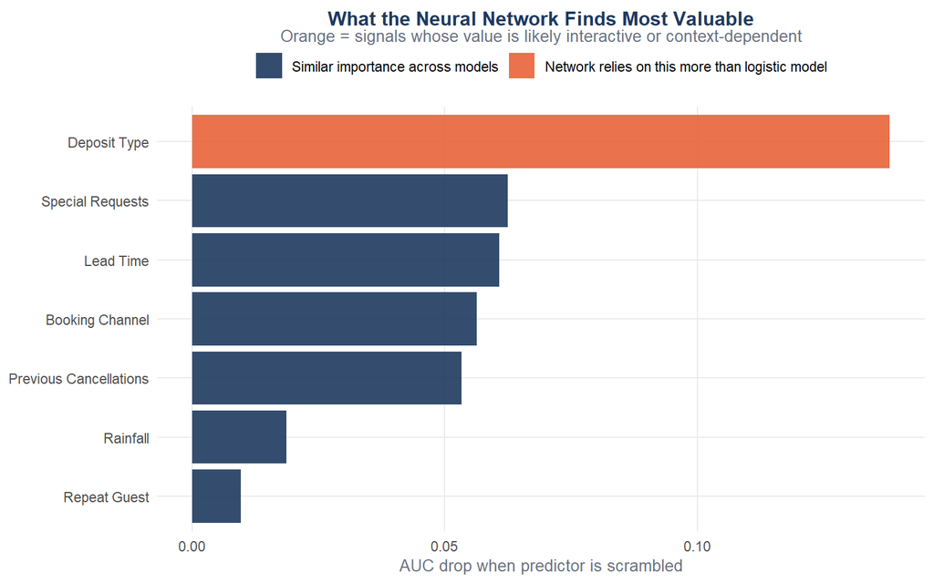

```r
set.seed(2026)
baseline_auc <- as.numeric(roc_nn$auc)

permute_auc <- function(j) {
  Xp <- nn_test$X; Xp[, j] <- sample(Xp[, j])
  p <- as.numeric(predict(fit_nn, Xp, type = "raw"))
  baseline_auc - as.numeric(pROC::auc(nn_test$y, p, levels = c("Stay","Cancel"),
                                       direction = "<", quiet = TRUE))
}

perm_drops <- sapply(seq_len(ncol(nn_test$X)), permute_auc)
names(perm_drops) <- colnames(nn_test$X)

predictor_root <- function(col) {
  for (var in c("DepositType","MarketSegment")) {
    if (startsWith(col, var)) return(var)
  }
  col
}

perm_df <- data.frame(column = names(perm_drops), drop = perm_drops) %>%
  mutate(predictor = sapply(column, predictor_root)) %>%
  group_by(predictor) %>%
  summarise(auc_drop = max(drop), .groups = "drop") %>%
  arrange(desc(auc_drop)) %>%
  mutate(predictor_clean = dplyr::recode(predictor,
    "LeadTime"               = "Lead Time",
    "DepositType"            = "Deposit Type",
    "MarketSegment"          = "Booking Channel",
    "PreviousCancellations"  = "Previous Cancellations",
    "TotalOfSpecialRequests" = "Special Requests",
    "IsRepeatedGuest"        = "Repeat Guest",
    "precipitation_mm"       = "Rainfall"
  ))

glm_z <- summary(model_binomial)$coefficients[, "z value"]
glm_imp <- data.frame(column = names(glm_z), z = abs(glm_z)) %>%
  filter(column != "(Intercept)") %>%
  mutate(predictor = sapply(column, predictor_root)) %>%
  group_by(predictor) %>%
  summarise(glm_z = max(z), .groups = "drop")

perm_df <- perm_df %>%
  left_join(glm_imp, by = "predictor") %>%
  mutate(nn_rank   = rank(-auc_drop, ties.method = "first"),
         glm_rank  = rank(-glm_z,    ties.method = "first"),
         nn_higher = (glm_rank - nn_rank) >= 2)

ggplot(perm_df, aes(x = auc_drop, y = reorder(predictor_clean, auc_drop),
                    fill = nn_higher)) +
  geom_col(alpha = 0.9) +
  scale_fill_manual(values = c("TRUE" = P$orange, "FALSE" = P$navy),
                    labels = c("TRUE" = "Network relies on this more than logistic model",
                               "FALSE" = "Similar importance across models"), name = NULL) +
  labs(title = "What the Neural Network Finds Most Valuable",
       subtitle = "Orange = signals whose value is likely interactive or context-dependent",
       x = "AUC drop when predictor is scrambled", y = NULL) +
  theme_report() +
  theme(legend.position = "top")
```

# 9 How Do the Models Compare?

```r
eval_glm_gam <- function(prob, label) {
  prob  <- as.numeric(prob)
  truth <- as.integer(test_bin$IsCanceled)
  ok    <- is.finite(prob) & !is.na(truth)
  prob  <- prob[ok]; truth <- truth[ok]
  pred  <- factor(ifelse(prob > 0.5, 1, 0), levels = c(0,1))
  cm    <- caret::confusionMatrix(pred, factor(truth, levels = c(0,1)), positive = "1")
  rocp  <- pROC::roc(truth, prob, quiet = TRUE)
  prc   <- PRROC::pr.curve(scores.class0 = prob[truth==1],
                            scores.class1 = prob[truth==0], curve = FALSE)
  data.frame(Model    = label,
             Accuracy = unname(cm$overall["Accuracy"]),
             ROC_AUC  = as.numeric(rocp$auc),
             F1       = unname(cm$byClass["F1"]),
             PR_AUC   = prc$auc.integral)
}

comparison_table <- rbind(
  eval_glm_gam(pred_probs_bin, "Logistic Model"),
  eval_glm_gam(gam_probs,      "Curve Model (GAM)"),
  svm_results,
  nn_results
)
rownames(comparison_table) <- NULL

kable(comparison_table, digits = 4,
      caption = "Table 7: Head-to-head comparison of all four cancellation models on identical held-out data. Best performance in each column highlighted.",
      col.names = c("Model", "Accuracy", "AUC", "F1 Score", "PR-AUC")) %>%
  kable_styling(full_width = FALSE, font_size = 11,
                bootstrap_options = c("striped", "hover")) %>%
  row_spec(which.max(comparison_table$ROC_AUC), bold = TRUE, background = "#EBF2FA") %>%
  row_spec(0, color = "white", background = "#1E3A5F")
```

Table 7: Head-to-head comparison of all four cancellation models on identical held-out data. Best performance in each column highlighted.

| Model | Accuracy | AUC | F1 Score | PR-AUC |
| --- | --- | --- | --- | --- |
| Logistic Model | 0.7934 | 0.8393 | 0.7083 | 0.8389 |
| Curve Model (GAM) | 0.8002 | 0.8453 | 0.7283 | 0.8411 |
| SVM (Linear kernel) | 0.7623 | 0.8347 | 0.6070 | 0.8273 |
| SVM (RBF kernel) | 0.7999 | 0.8411 | 0.7316 | 0.8456 |
| Neural Network | 0.8126 | 0.8695 | 0.7553 | 0.8665 |

Note on Metrics: Accuracy alone is insufficient for cancellation data. We include F1 Score and PR-AUC to measure the balance between “False Alarms” (lost revenue from overbooking) and “Missed Cancellations” (lost revenue from empty rooms). High scores in these metrics ensure the model is operationally reliable for inventory management.

## 9.1 What the Progression Tells Us

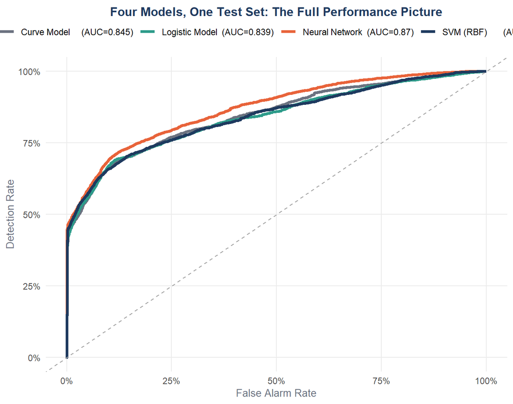

```r
bind_rows(
  data.frame(fpr=1-roc_bin$specificities, tpr=roc_bin$sensitivities,
             Model=paste0("Logistic Model  (AUC=", round(auc(roc_bin),3),")")),
  data.frame(fpr=1-roc_gam$specificities, tpr=roc_gam$sensitivities,
             Model=paste0("Curve Model     (AUC=", round(auc(roc_gam),3),")")),
  data.frame(fpr=1-roc_rbf$specificities, tpr=roc_rbf$sensitivities,
             Model=paste0("SVM (RBF)       (AUC=", round(auc(roc_rbf),3),")")),
  data.frame(fpr=1-roc_nn$specificities,  tpr=roc_nn$sensitivities,
             Model=paste0("Neural Network  (AUC=", round(auc(roc_nn), 3),")"))
) %>%
  ggplot(aes(x = fpr, y = tpr, colour = Model)) +
  geom_line(linewidth = 1.3) +
  geom_abline(slope = 1, intercept = 0, linetype = "dashed", colour = "grey65") +
  scale_colour_manual(values = c(P$grey, P$teal, P$orange, P$navy)) +
  scale_x_continuous(labels = scales::percent_format()) +
  scale_y_continuous(labels = scales::percent_format()) +
  labs(title = "Four Models, One Test Set: The Full Performance Picture",
       x = "False Alarm Rate", y = "Detection Rate", colour = NULL) +
  theme_report() +
  theme(legend.position = "top")
```

The linear-kernel SVM sits close to the logistic model, confirming the RBF gain is from interaction learning, not from the SVM training method itself.

# 10 Recommendations

This analysis applied six models to 79,330 city hotel bookings, answering three operationally distinct questions.

**On pricing.** Room type and booking channel are the dominant price drivers; they explain far more variation than timing or weather. Direct bookings sustain the highest rates, providing a clear commercial argument for shifting volume from OTA to direct channels. A genuine early-booking discount exists in the data, controlled for everything else: last-minute rates can carry a modest premium, and tiered early-bird pricing is evidence-backed. The model predicts nightly rates within ±€29.1 on unseen bookings, explaining 46.7% of price variation.

**On stay length.** Corporate guests stay the shortest; this is structural and unlikely to respond to promotions. Full-board and half-board guests stay meaningfully longer than bed-and-breakfast guests, confirming that inclusive packages attract a different, longer-stay traveller profile. The clearest incremental revenue opportunity is a third-night or fourth-night discount offered at booking confirmation for Online TA leisure guests arriving in Summer; the combination of highest volume, longest baseline stay, and strongest evidence.

**A unifying finding.** The same predictor set (lead time, booking channel, deposit type, special requests, prior cancellation history, repeat guest status, and seasonal rainfall) drives all three outcomes. A guest who books directly, far ahead, submits special requests, and has no cancellation history pays more, stays longer, and is dramatically less likely to cancel. Revenue management optimising for any one of these dimensions in isolation is leaving value on the table.

# 11 Limitations

**Weather granularity.** Weather variables are monthly averages; every booking in the same arrival month receives identical values. This captures seasonal climate effects but provides no within-month signal. Marginal weather contributions should be read accordingly.

**The Non Refund recording artefact.** The near-100% cancellation rate for Non Refund bookings likely reflects office recording conventions rather than guest behavior. While relative model rankings remain valid, future work should retrain models without this variable to isolate pure behavioral signals and verify organic predictive power.

**SVM training subsample.** The kernel SVM was fitted on a stratified 5,000-row subsample due to computational constraints. Test-set performance is directly comparable to the other models; the subsample introduces some variance in hyperparameter selection but not in the reported test metrics.

**SVM probability calibration.** SVM decision values are not probabilities. To compute threshold-dependent metrics (Accuracy, F1), decision values are z-standardised and mapped through a sigmoid function — a pragmatic approximation rather than formal Platt scaling. AUC comparisons are unaffected by this, as AUC is threshold-free. Accuracy and F1 figures for the SVM should be interpreted with this in mind.

**Single property and time period.** These findings reflect one Lisbon city hotel over 25 months, 2015–2017. Extending the models to other properties, or to post-pandemic booking behaviour, would require revalidation, not just retraining.

# 12 AI Usage Statement

Generative AI like Claude and Gemini were used throughout this project primarily for code-related tasks: debugging R errors, suggesting idiomatic syntax for packages such as mgcv, kernlab, and kableExtra, and helping restructure prose for clarity. It was also used to explain statistical concepts during the work, for example, clarifying the interpretation of quasi-Poisson dispersion ratios and EDF values in GAM output. What AI handled well was repetitive or syntactic work: fixing YAML errors, reformatting ggplot code, and producing first drafts of narrative text. What it could not do reliably was make correct statistical judgements, on several occasions it produced interpretations that were factually wrong, such as describing an overdispersion ratio below 1 as confirming overdispersion, or conflating AUC with classification accuracy. These errors required the team to catch and correct them by returning to course material and the original model output. The main lesson was that AI-generated statistical language must be verified against the actual numbers and against what the model assumptions require, accepting the output uncritically would have introduced errors into the final analysis.

# 13 References

Antonio, N., de Almeida, A., & Nunes, L. (2019). Hotel booking demand datasets. *Data in Brief*, 22, 41–49. https://doi.org/10.1016/j.dib.2018.11.126

Open-Meteo Historical Weather API. Retrieved from https://open-meteo.com